# Proyecto Modulo 2 - Parte 1. Vuelos de NYC

Authors

Becerra Ayala Anay

Diaz Cuevas Bruno

Patiño Gonzalez Brandon

Olvera Galeana Enrique

David Suarez Lopez

```r
knitr::opts_chunk$set(message = FALSE, warning = FALSE)
```

En este proyecto se analiza la base de datos `vuelos.db`, que contiene información de vuelos en NYC durante 2013.

Se utilizaran las tablas de la base de datos `vuelos.db` que incluye información de:

- flights: Detalles de todos los vuelos que salieron de NYC (JFK, LGA, EWR) en 2013.
- airlines: Códigos y nombres de aerolíneas.
- airports: Información sobre aeropuertos, incluyendo ubicación.
- planes: Datos sobre aeronaves, incluyendo año de fabricación.
- weather: Datos meteorológicos por hora para los aeropuertos de NYC.

```r
#install.packages("DBI") #hace que r acceda a bases de datos
#install.packages("RSQLite") #lee archivos sql
#install.packages("dplyr") #manipula datos con filtros, select y mutate
#install.packages("dbplyr") #lleva de dplyr a sql
#install.packages("sqldf")
```

```r
#llamamos a las librerías respectivas de c/paquetería
library(DBI)
library(RSQLite)
library(dplyr)
library(dbplyr)
```

Lo primero que debemos hacer es ver los contenidos de vuelos.db y lo hacemos con la siguiente intrucción:

```r
con <- dbConnect(RSQLite::SQLite(),"vuelos.db") #conecta con vuelos,db

dbListTables(con) #nos pone las tablas que hay dentro
```

```
[1] "airlines" "airports" "flights"  "planes"   "weather"
```

```r
vuelos <- dbReadTable(con, "flights") #pone las tablas en r como dataframe
head(vuelos)  #muestra los primeros resultados de la tabla vuelos
```

```
  year month day dep_time sched_dep_time dep_delay arr_time sched_arr_time
1 2013     1   1      517            515         2      830            819
2 2013     1   1      533            529         4      850            830
3 2013     1   1      542            540         2      923            850
4 2013     1   1      544            545        -1     1004           1022
5 2013     1   1      554            600        -6      812            837
6 2013     1   1      554            558        -4      740            728
  arr_delay carrier flight tailnum origin dest air_time distance hour minute
1        11      UA   1545  N14228    EWR  IAH      227     1400    5     15
2        20      UA   1714  N24211    LGA  IAH      227     1416    5     29
3        33      AA   1141  N619AA    JFK  MIA      160     1089    5     40
4       -18      B6    725  N804JB    JFK  BQN      183     1576    5     45
5       -25      DL    461  N668DN    LGA  ATL      116      762    6      0
6        12      UA   1696  N39463    EWR  ORD      150      719    5     58
   time_hour
1 1357034400
2 1357034400
3 1357034400
4 1357034400
5 1357038000
6 1357034400
```

```r
tail(vuelos) #muestra los ultimos resultado de la tabla vuelos
```

```
       year month day dep_time sched_dep_time dep_delay arr_time sched_arr_time
336771 2013     9  30       NA           1842        NA       NA           2019
336772 2013     9  30       NA           1455        NA       NA           1634
336773 2013     9  30       NA           2200        NA       NA           2312
336774 2013     9  30       NA           1210        NA       NA           1330
336775 2013     9  30       NA           1159        NA       NA           1344
336776 2013     9  30       NA            840        NA       NA           1020
       arr_delay carrier flight tailnum origin dest air_time distance hour
336771        NA      EV   5274  N740EV    LGA  BNA       NA      764   18
336772        NA      9E   3393    <NA>    JFK  DCA       NA      213   14
336773        NA      9E   3525    <NA>    LGA  SYR       NA      198   22
336774        NA      MQ   3461  N535MQ    LGA  BNA       NA      764   12
336775        NA      MQ   3572  N511MQ    LGA  CLE       NA      419   11
336776        NA      MQ   3531  N839MQ    LGA  RDU       NA      431    8
       minute  time_hour
336771     42 1380578400
336772     55 1380564000
336773      0 1380592800
336774     10 1380556800
336775     59 1380553200
336776     40 1380542400
```

```r
#vuelos_tbl <- tbl(con, "vuelos")  #llamamos a la tabla vuelos
vuelos_tbl <- dbGetQuery(con,"SELECT * FROM flights") #llamamos a la tabla vuelos

head(vuelos_tbl)
```

```
  year month day dep_time sched_dep_time dep_delay arr_time sched_arr_time
1 2013     1   1      517            515         2      830            819
2 2013     1   1      533            529         4      850            830
3 2013     1   1      542            540         2      923            850
4 2013     1   1      544            545        -1     1004           1022
5 2013     1   1      554            600        -6      812            837
6 2013     1   1      554            558        -4      740            728
  arr_delay carrier flight tailnum origin dest air_time distance hour minute
1        11      UA   1545  N14228    EWR  IAH      227     1400    5     15
2        20      UA   1714  N24211    LGA  IAH      227     1416    5     29
3        33      AA   1141  N619AA    JFK  MIA      160     1089    5     40
4       -18      B6    725  N804JB    JFK  BQN      183     1576    5     45
5       -25      DL    461  N668DN    LGA  ATL      116      762    6      0
6        12      UA   1696  N39463    EWR  ORD      150      719    5     58
   time_hour
1 1357034400
2 1357034400
3 1357034400
4 1357034400
5 1357038000
6 1357034400
```

Tabla de aerolineas:

```r
aerolineas_tbl <- dbGetQuery(con,"SELECT * FROM airlines")
aerolineas_tbl
```

```
   carrier                        name
1       9E           Endeavor Air Inc.
2       AA      American Airlines Inc.
3       AS        Alaska Airlines Inc.
4       B6             JetBlue Airways
5       DL        Delta Air Lines Inc.
6       EV    ExpressJet Airlines Inc.
7       F9      Frontier Airlines Inc.
8       FL AirTran Airways Corporation
9       HA      Hawaiian Airlines Inc.
10      MQ                   Envoy Air
11      OO       SkyWest Airlines Inc.
12      UA       United Air Lines Inc.
13      US             US Airways Inc.
14      VX              Virgin America
15      WN      Southwest Airlines Co.
16      YV          Mesa Airlines Inc.
```

## 1. ¿Qué aerolínea tuvo el mayor retraso promedio en la salida en 2013?

- Utilizando verbos de dplyr

Calculamos el retraso promedio por aerolinea y ordenamos de mayor a menor. Podemos observar que la aerolinea con mayor retraso promedio es F9 con 20.21 minutos , que de acuerdo a la tabla de aerolineas corresponde a Frontier Airlines Inc.

```r
vuelos %>%
  group_by(carrier) %>% #Agrupar por aerolinea
  summarise(retraso_promedio = mean(dep_delay, na.rm = TRUE)) %>% #Calcular promedio de retraso (ignorando nan)
  arrange(desc(retraso_promedio)) #Ordenar de mayor a menor
```

```
# A tibble: 16 × 2
   carrier retraso_promedio
   <chr>              <dbl>
 1 F9                 20.2
 2 EV                 20.0
 3 YV                 19.0
 4 FL                 18.7
 5 WN                 17.7
 6 9E                 16.7
 7 B6                 13.0
 8 VX                 12.9
 9 OO                 12.6
10 UA                 12.1
11 MQ                 10.6
12 DL                  9.26
13 AA                  8.59
14 AS                  5.80
15 HA                  4.90
16 US                  3.78
```

- Utilizando SQL obtenemos el mismo resultado:

```r
Aerolinea_mayor_retraso_promedio <- dbGetQuery(con,
"SELECT carrier, AVG(dep_delay) AS retraso_promedio
FROM flights WHERE year= 2013
GROUP BY carrier
ORDER BY retraso_promedio DESC
")

Aerolinea_mayor_retraso_promedio
```

```
   carrier retraso_promedio
1       F9        20.215543
2       EV        19.955390
3       YV        18.996330
4       FL        18.726075
5       WN        17.711744
6       9E        16.725769
7       B6        13.022522
8       VX        12.869421
9       OO        12.586207
10      UA        12.106073
11      MQ        10.552041
12      DL         9.264505
13      AA         8.586016
14      AS         5.804775
15      HA         4.900585
16      US         3.782418
```

Siendo F9 la erolinea con mayor retraso.

## 2. ¿Qué día de la semana tuvo más vuelos retrasados en promedio?

El primer paso es utilizar las columnas year, month y day para crear una columna fecha y calcular el dia de la semana:

```r
vuelos_tbl$date <- as.Date(paste(vuelos_tbl$year, vuelos_tbl$month, vuelos_tbl$day, sep = "-"))
vuelos_tbl$weekday <- weekdays(vuelos_tbl$date)
```

Calculamos la tasa de retraso:

$$\frac{\text{# vuelos retrasados}}{\text{# total vuelos}}$$

- Utilizando verbos de dply

Calculando la tasa de vuelos retrasados por dia de la semana observamos que el 43% de los vuelos salen con retraso los jueves, convirtiéndolo en el dia con mayor porcentaje de vuelos retrasados.

```r
vuelos_tbl %>%
  group_by(weekday) %>%
  summarise( tasa_retraso = mean(dep_delay > 0, na.rm = TRUE) ) %>%
  arrange(desc(tasa_retraso))
```

```
# A tibble: 7 × 2
  weekday   tasa_retraso
  <chr>            <dbl>
1 jueves           0.432
2 viernes          0.425
3 lunes            0.401
4 domingo          0.383
5 miércoles        0.373
6 martes           0.364
7 sábado           0.348
```

```r
library(sqldf)

sqldf(" SELECT weekday,
  AVG( CASE
    WHEN dep_delay > 0
    THEN 1.0
    ELSE 0.0
    END) AS tasa_retraso
  FROM vuelos_tbl
  GROUP BY weekday
  ORDER BY tasa_retraso DESC
")
```

```
    weekday tasa_retraso
1    jueves    0.4183078
2   viernes    0.4118430
3     lunes    0.3914973
4   domingo    0.3772246
5 miércoles    0.3637235
6    martes    0.3560152
7    sábado    0.3412965
```

Jueves es el día con mayor tasa de vuelos retrasados con aproximadamente el 41.8%.

## 3. ¿Cuál es la distribución de los retrasos en la salida para cada aeropuerto?

Para determinar como se distribuyen los retrasos por cada aeropuerto, calculamos la media y el rango por cada grupo:

- Utilizando verbos de dply

```r
  vuelos_tbl %>%
    group_by(origin) %>% # Agrupa por aeropuerto de salida
    summarise( # Calcula la media, mediana, sd, min y max
      media_retraso = mean(dep_delay, na.rm = TRUE),
      retraso_minimo = min(dep_delay, na.rm = TRUE),
      retraso_maximo = max(dep_delay, na.rm = TRUE)
    ) %>%
    arrange(desc(media_retraso)) # Ordenar por media de retraso
```

```
# A tibble: 3 × 4
  origin media_retraso retraso_minimo retraso_maximo
  <chr>          <dbl>          <dbl>          <dbl>
1 EWR             15.1            -25           1126
2 JFK             12.1            -43           1301
3 LGA             10.3            -33            911
```

- SQL

```r
Distribucion_retrasos_aeropuerto <- dbGetQuery(con,
"
SELECT
  origin,
  AVG(dep_delay) AS promedio_retraso,
  MIN(dep_delay) AS retraso_minimo,
  MAX(dep_delay) AS retraso_maximo
FROM flights
GROUP BY origin
ORDER BY promedio_retraso DESC
")

Distribucion_retrasos_aeropuerto
```

```
  origin promedio_retraso retraso_minimo retraso_maximo
1    EWR         15.10795            -25           1126
2    JFK         12.11216            -43           1301
3    LGA         10.34688            -33            911
```

EWR tiene el mayor retraso promedio, mientras que JFK tiene valores extremos más altos. Los valores negativos en los vuelos son aquellos que salieron antes de lo programado. Se observan valores extremos en los retrasos máximos, lo que indica la presencia de outliers en los datos. A pesar de esto, el aeropuerto EWR presenta el mayor retraso promedio.

## 4. ¿Qué proporción de vuelos se retrasaron más de 30 minutos?

```r
con <- dbConnect(RSQLite::SQLite(), "vuelos.db")

dbListTables(con)# ver tablas
```

```
[1] "airlines" "airports" "flights"  "planes"   "weather"
```

```r
vuelos_tbl <- tbl(con, "flights")  #llamamos a la tabla vuelos
```

Consecuentemente, vamos a filtrar los vuelos con retraso mayor a los 30 minutos de despegue como se muestra a continuación y haremos un conteo:

```r
vuelos_tbl %>% #usa la tabla de vuelos
  filter(dep_delay>30) %>% #filtra los vuelos con retraso de más de 30 minutos
  summarise(total=n()) %>% #se hace conteo de los vuelos con retraso
  collect() #da solo el número de vuelos con retraso
```

```
# A tibble: 1 × 1
  total
  <int>
1 48291
```

```r
vuelos_tbl
```

```
# Source:   table<`flights`> [?? x 19]
# Database: sqlite 3.52.0 [C:\Users\Latitude\Downloads\vuelos.db]
    year month   day dep_time sched_dep_time dep_delay arr_time sched_arr_time
   <int> <int> <int>    <int>          <int>     <dbl>    <int>          <int>
 1  2013     1     1      517            515         2      830            819
 2  2013     1     1      533            529         4      850            830
 3  2013     1     1      542            540         2      923            850
 4  2013     1     1      544            545        -1     1004           1022
 5  2013     1     1      554            600        -6      812            837
 6  2013     1     1      554            558        -4      740            728
 7  2013     1     1      555            600        -5      913            854
 8  2013     1     1      557            600        -3      709            723
 9  2013     1     1      557            600        -3      838            846
10  2013     1     1      558            600        -2      753            745
# ℹ more rows
# ℹ 11 more variables: arr_delay <dbl>, carrier <chr>, flight <int>,
#   tailnum <chr>, origin <chr>, dest <chr>, air_time <dbl>, distance <dbl>,
#   hour <dbl>, minute <dbl>, time_hour <dbl>
```

Haremos lo mismo que hicimos anteriormente, pero usando SQL:

```r
vuelos_retmayo30 <-dbGetQuery(con, "SELECT*FROM flights
                                   WHERE dep_delay>30")
dim(vuelos_retmayo30) #nos da la cantidad vuelos retrasados por número de filas
```

```
[1] 48291    19
```

```r
head(vuelos_retmayo30) #pedimos los primeros datos del qery
```

```
  year month day dep_time sched_dep_time dep_delay arr_time sched_arr_time
1 2013     1   1      732            645        47     1011            941
2 2013     1   1      749            710        39      939            850
3 2013     1   1      811            630       101     1047            830
4 2013     1   1      826            715        71     1136           1045
5 2013     1   1      848           1835       853     1001           1950
6 2013     1   1      903            820        43     1045            955
  arr_delay carrier flight tailnum origin dest air_time distance hour minute
1        30      UA   1111  N37456    EWR  MCO      145      937    6     45
2        49      MQ   3737  N508MQ    EWR  ORD      148      719    7     10
3       137      MQ   4576  N531MQ    LGA  CLT      118      544    6     30
4        51      AA    443  N3GVAA    JFK  MIA      160     1089    7     15
5       851      MQ   3944  N942MQ    JFK  BWI       41      184   18     35
6        50      MQ   4655  N532MQ    LGA  BNA      142      764    8     20
   time_hour
1 1357038000
2 1357041600
3 1357038000
4 1357041600
5 1357081200
6 1357045200
```

```r
tail(vuelos_retmayo30) #pedimos los ultimos datos del qery
```

```
      year month day dep_time sched_dep_time dep_delay arr_time sched_arr_time
48286 2013     9  30     2114           2025        49     2304           2228
48287 2013     9  30     2119           2005        74     2310           2212
48288 2013     9  30     2159           1845       194     2344           2030
48289 2013     9  30     2211           2059        72     2339           2242
48290 2013     9  30     2233           2113        80      112             30
48291 2013     9  30     2235           2001       154       59           2249
      arr_delay carrier flight tailnum origin dest air_time distance hour
48286        36      EV   4348  N11184    EWR  MSP      145     1008   20
48287        58      EV   4321  N17984    EWR  MCI      147     1092   20
48288       194      9E   3320  N906XJ    JFK  BUF       50      301   18
48289        57      EV   4672  N12145    EWR  STL      120      872   20
48290        42      UA    471  N578UA    EWR  SFO      318     2565   21
48291       130      B6   1083  N804JB    JFK  MCO      123      944   20
      minute  time_hour
48286     25 1380585600
48287      5 1380585600
48288     45 1380578400
48289     59 1380585600
48290     13 1380589200
48291      1 1380585600
```

```r
vuelos_retmayo30 <-dbGetQuery(con, "SELECT*FROM flights
                                   WHERE dep_delay>30
                                  ORDER BY dep_delay ASC")
dim(vuelos_retmayo30)
```

```
[1] 48291    19
```

```r
head(vuelos_retmayo30)
```

```
  year month day dep_time sched_dep_time dep_delay arr_time sched_arr_time
1 2013     1   1     1430           1359        31     1718           1652
2 2013     1   1     1756           1725        31     2036           2019
3 2013     1   1     2026           1955        31     2205           2120
4 2013     1   2      801            730        31     1136           1040
5 2013     1   2     1256           1225        31     1409           1345
6 2013     1   2     1940           1909        31     2226           2122
  arr_delay carrier flight tailnum origin dest air_time distance hour minute
1        26      UA    278  N563UA    EWR  PBI      149     1023   13     59
2        17      UA    376  N523UA    EWR  MCO      140      937   17     25
3        45      WN    195  N957WN    EWR  MDW      134      711   19     55
4        56      AA   2083  N487AA    EWR  DFW      241     1372    7     30
5        24      WN    408  N936WN    EWR  MDW      114      711   12     25
6        64      EV   4085  N12135    EWR  OMA      208     1134   19      9
   time_hour
1 1357063200
2 1357077600
3 1357084800
4 1357128000
5 1357146000
6 1357171200
```

```r
tail(vuelos_retmayo30)
```

```
      year month day dep_time sched_dep_time dep_delay arr_time sched_arr_time
48286 2013     4  10     1100           1900       960     1342           2211
48287 2013     7  22      845           1600      1005     1044           1815
48288 2013     9  20     1139           1845      1014     1457           2210
48289 2013     1  10     1121           1635      1126     1239           1810
48290 2013     6  15     1432           1935      1137     1607           2120
48291 2013     1   9      641            900      1301     1242           1530
      arr_delay carrier flight tailnum origin dest air_time distance hour
48286       931      DL   2391  N959DL    JFK  TPA      139     1005   19
48287       989      MQ   3075  N665MQ    JFK  CVG       96      589   16
48288      1007      AA    177  N338AA    JFK  SFO      354     2586   18
48289      1109      MQ   3695  N517MQ    EWR  ORD      111      719   16
48290      1127      MQ   3535  N504MQ    JFK  CMH       74      483   19
48291      1272      HA     51  N384HA    JFK  HNL      640     4983    9
      minute  time_hour
48286      0 1365634800
48287      0 1374523200
48288     45 1379714400
48289     35 1357851600
48290     35 1371337200
48291      0 1357740000
```

Para obtener la proporción de los vuelos con retrasos mayores o iguales a los $30$ minutos, podemos aplicar la siguiente función:

$N_{proporcionret}=\frac{N_{vuelos_retmayo30}}{N_{vuelos_totales}}$

```r
#seleccionamos los datos del total de retrasados
vuelos_totales <- dbGetQuery(con,"SELECT COUNT(*) FROM flights")
n_retrasados <- nrow(vuelos_retmayo30)
#registramos una nueva variable que ontiene el número de renglones de vuelos
#con retraso mayor a 30 minutos
```

Por otro lado, me interesa saber los vuelos retrasados en porcentaje por más de 30 minutos:

```r
N_proporcionret <- n_retrasados/vuelos_totales$'COUNT(*)'
#hacemos la división entre el número de vuelos con retraso con el conteo de renglones y el número de renglones de vuelos totales
N_proporcionret*100 #se multiplica por 100 para sacar el porcentaje
```

```
[1] 14.3392
```

```r
N_proporciont <-((vuelos_totales-n_retrasados)/vuelos_totales)*100
N_proporciont
```

```
  COUNT(*)
1  85.6608
```

Y el $85.66\%$ de los vuelos no sufren retrasos mayor a 30 minutos.

Por otro lado, si usamos la sintaxis de dplyr, tenemos que:

```r
library(ggplot2) #llamamos ggplot2 para hacer las graficas
```

También, vamos a crear la variable que nos diga los vuelos que tienen retraso menor a $30$ minutos, para poder usarlo en nuestra gráfica con ggplot2 y dplyr

```r
#usamos dply para filtrar el número de vuelos con retraso menor a los 30 minutos
vuelos_tbl %>%
  filter(dep_delay<30) %>%
  summarise(total=n()) %>%
  collect()
```

```
# A tibble: 1 × 1
   total
   <int>
1 279108
```

Siendo el mismo valor obtenido por SQL.

```r
#hacemos  nuestro qery de vuelos con retraso menor a 30 minutos
vuelos_retmen30 <-dbGetQuery(con, "SELECT*FROM flights
                                   WHERE dep_delay<30")
dim(vuelos_retmen30)
```

```
[1] 279108     19
```

```r
head(vuelos_retmen30)
```

```
  year month day dep_time sched_dep_time dep_delay arr_time sched_arr_time
1 2013     1   1      517            515         2      830            819
2 2013     1   1      533            529         4      850            830
3 2013     1   1      542            540         2      923            850
4 2013     1   1      544            545        -1     1004           1022
5 2013     1   1      554            600        -6      812            837
6 2013     1   1      554            558        -4      740            728
  arr_delay carrier flight tailnum origin dest air_time distance hour minute
1        11      UA   1545  N14228    EWR  IAH      227     1400    5     15
2        20      UA   1714  N24211    LGA  IAH      227     1416    5     29
3        33      AA   1141  N619AA    JFK  MIA      160     1089    5     40
4       -18      B6    725  N804JB    JFK  BQN      183     1576    5     45
5       -25      DL    461  N668DN    LGA  ATL      116      762    6      0
6        12      UA   1696  N39463    EWR  ORD      150      719    5     58
   time_hour
1 1357034400
2 1357034400
3 1357034400
4 1357034400
5 1357038000
6 1357034400
```

```r
tail(vuelos_retmen30)
```

```
       year month day dep_time sched_dep_time dep_delay arr_time sched_arr_time
279103 2013     9  30     2237           2245        -8     2345           2353
279104 2013     9  30     2240           2245        -5     2334           2351
279105 2013     9  30     2240           2250       -10     2347              7
279106 2013     9  30     2241           2246        -5     2345              1
279107 2013     9  30     2307           2255        12     2359           2358
279108 2013     9  30     2349           2359       -10      325            350
       arr_delay carrier flight tailnum origin dest air_time distance hour
279103        -8      B6    234  N318JB    JFK  BTV       43      266   22
279104       -17      B6   1816  N354JB    JFK  SYR       41      209   22
279105       -20      B6   2002  N281JB    JFK  BUF       52      301   22
279106       -16      B6    486  N346JB    JFK  ROC       47      264   22
279107         1      B6    718  N565JB    JFK  BOS       33      187   22
279108       -25      B6    745  N516JB    JFK  PSE      196     1617   23
       minute  time_hour
279103     45 1380592800
279104     45 1380592800
279105     50 1380592800
279106     46 1380592800
279107     55 1380592800
279108     59 1380596400
```

Entonces respondemos con base a lo visto: ¿Qué proporción de vuelos se retrasaron más de 30 minutos?

Haciendo un gráfico de barras y con base a la tabla del qery tenemos lo siguiente:

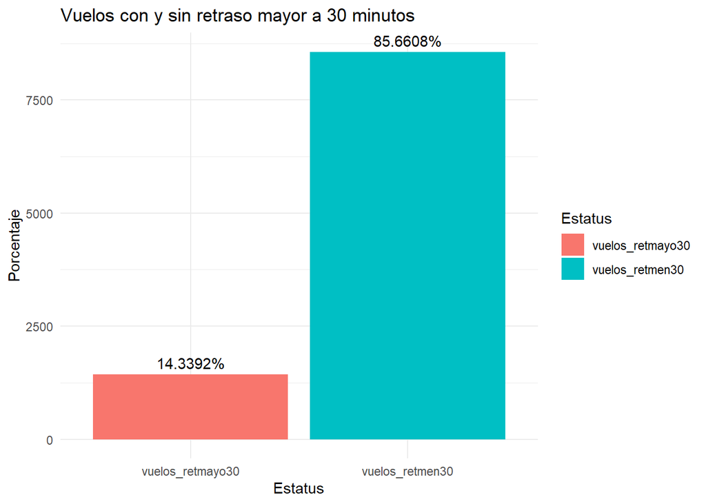

```r
data.frame(
  Estatus=c("vuelos_retmayo30", "vuelos_retmen30"),
  Proporcion=c(N_proporcionret*100,(1-N_proporcionret)*100)
  )%>%
  ggplot(aes(x=Estatus, y=Proporcion*100,fill=Estatus))+
  geom_col()+
  geom_text(aes(label=paste0(round(Proporcion,4),"%")),vjust=-0.5)+
  labs(y="Porcentaje", title="Vuelos con y sin retraso mayor a 30 minutos")+
  theme_minimal()
```

Por ende, vemos que $\approx 85.66$ de los vuelos llego con retraso menor a $30$ minutos y que $\approx 14.33$ de los vuelos llegaron con retraso mayor a los $30$ minutos.

## 5. ¿Qué destinos tuvieron los mayores retrasos promedio en la llegada?

Por otro lado, si queremos saber los destinos con mayores retrasos usando dplyr, podemos tomar el promedio de los totales o los que son mayores a $30$ minutos. Es decir, para los que son mayores a $30$ minutos:

```r
#llamamos una tabla con los destinos con retraso mayor a 30 minutos
#usando dplyr
destino_retmay30 <- vuelos %>%
  filter(!is.na(arr_delay))%>% #filtramos con la tardanza de llegada
  group_by(dest) %>% #usamos el nombre del destino
  summarise(
    total_vuelos=n(), #contamos totdos los vuelos totales
    pct_retraso_30=mean(arr_delay>30,na.rm=TRUE)*100 #sacamos un porcentaje de los vuelos retrasados
  )%>%
  filter(total_vuelos>100)%>% #solo tomamos destinos muy visitados
  arrange(desc(pct_retraso_30)) #ordena los destinos de mayor a menor retraso

destino_retmay30 #llamamos la tabla ordenda
```

```
# A tibble: 92 × 3
   dest  total_vuelos pct_retraso_30
   <chr>        <int>          <dbl>
 1 CAE            106           48.1
 2 OKC            315           38.4
 3 TUL            294           37.8
 4 TYS            578           30.4
 5 DSM            523           27.3
 6 BHM            269           26.8
 7 MSN            556           26.6
 8 RIC           2346           25.8
 9 CRW            134           25.4
10 GSP            790           25.1
# ℹ 82 more rows
```

Vizualizando los datos:

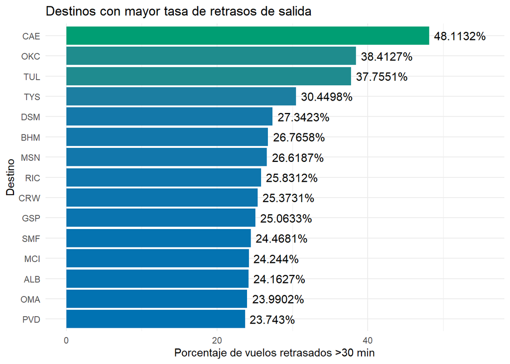

```r
#graficamos los destinos con ggplot2 que sufren mayor retraso
desti_frec <- vuelos %>% #usamos la data de vuelos.db
  filter(!is.na(arr_delay)) %>% #filtramos por tiempo de llegada
  group_by(dest) %>% #agrupamos los destinos
  summarise(
    total = n(),
    retrasados = sum(arr_delay > 30), #sumamos los casos totales de tiempo de llegada mayor a 30 minutos
    pct_retraso = retrasados / total * 100 #calculamos el porcentaje de retraso de llegada por destino
  ) %>%
  filter(total > 100) %>%  # Quita destinos con pocos vuelos
  slice_max(pct_retraso, n = 15) #solo visualizaremos 15, para no aturdir con muchos datod

ggplot(desti_frec, aes(x = reorder(dest, pct_retraso), y = pct_retraso)) +
  geom_col(aes(fill = pct_retraso)) + #definimos el llenado con el porcentaje de vuelos retrasados
  geom_text(aes(label = paste0(round(pct_retraso, 4), "%")), #redondeamos a 4 cifras
            hjust = -0.1, size = 4) +
  coord_flip() +
  scale_fill_gradient(low = "#0072B2", high = "#009E73") + #definimos escala de color de barras
  labs(x = "Destino", y = "Porcentaje de vuelos retrasados >30 min",
       title = "Destinos con mayor tasa de retrasos de salida") +
  theme_minimal() +
  theme(legend.position = "none") +
  ylim(0, max(desti_frec$pct_retraso) * 1.15)  # Espacio para etiquetas
```

Por otro lado, si usamos la librería para hacer el qery de la frecuencia de retrasos de vuelos por aeropuerto, usamos el siguiente código con ayuda de la librería DBI:

```r
#si usamos query para visualizar una tabla
vuelos_retmayo30query <- "
  SELECT
    dest,
    COUNT(*) AS total_vuelos,
    SUM(CASE WHEN arr_delay > 30 THEN 1 ELSE 0 END) AS vuelos_retrasados_30,
    ROUND(SUM(CASE WHEN arr_delay > 30 THEN 1 ELSE 0 END) * 100.0000/ COUNT(*), 4) AS porcen_ret
  FROM flights
  WHERE arr_delay IS NOT NULL
  GROUP BY dest
  HAVING COUNT(*) > 100
  ORDER BY porcen_ret DESC
"

frec_retrasosmayo30 <- dbGetQuery(con, vuelos_retmayo30query)
frec_retrasosmayo30 #llamamos el qery con el calculo hecho
```

```
   dest total_vuelos vuelos_retrasados_30 porcen_ret
1   CAE          106                   51    48.1132
2   OKC          315                  121    38.4127
3   TUL          294                  111    37.7551
4   TYS          578                  176    30.4498
5   DSM          523                  143    27.3423
6   BHM          269                   72    26.7658
7   MSN          556                  148    26.6187
8   RIC         2346                  606    25.8312
9   CRW          134                   34    25.3731
10  GSP          790                  198    25.0633
11  SMF          282                   69    24.4681
12  MCI         1885                  457    24.2440
13  ALB          418                  101    24.1627
14  OMA          817                  196    23.9902
```

[output cut: 78 more lines]

Como vemos en el qery obtenido, donde obtenemos la frecuencia de vuelos por retraso dado al tiempo mayor a $30$ minutos, tenemos que para el aeropuerto metropolitano de Columbia (CAE), en segundo lugar tenemos al aeropuerto de la ciudad de Oklahoma (OKC) y en tercer lugar el aeropuerto de Tulsa (TUL). Lo que nos dice que sigen ocupando los mismo puestos en porcentaje de vuelos con retraso mayor a $30$ minutos.

## 6. ¿Qué aerolíneas tuvieron el mayor número de vuelos desde NYC?

Para esto, necesitamos tomar de la columna origin los tres aeropuertos principales de Nueva York, es decir, JFK, LGA y EWR.

```r
#con dply hacemos una frencia de aerolineas con mayor númro de vuelos
salida_frec_enNYC <- vuelos %>%  #usamos la base de datos vuelos.db
  filter(origin %in% c("LGA","EWR","JFK")) %>% #seleccionamos los tres aeropuertos de nueva york
  group_by(carrier) %>% #seleccionamos la aerolinea
  summarise(
    total_vuelos=n() #contamos todas las aerolineas
    )%>%
  #filter(total_vuelos>100)%>%
  arrange(desc(total_vuelos)) #vemos el total de los vuelos

salida_frec_enNYC #nos arroja las aerolineas con su cantidad de vuelos
```

```
# A tibble: 16 × 2
   carrier total_vuelos
   <chr>          <int>
 1 UA             58665
 2 B6             54635
 3 EV             54173
 4 DL             48110
 5 AA             32729
 6 MQ             26397
 7 US             20536
 8 9E             18460
 9 WN             12275
10 VX              5162
11 FL              3260
12 AS               714
13 F9               685
14 YV               601
15 HA               342
16 OO                32
```

Visualizamos los datos:

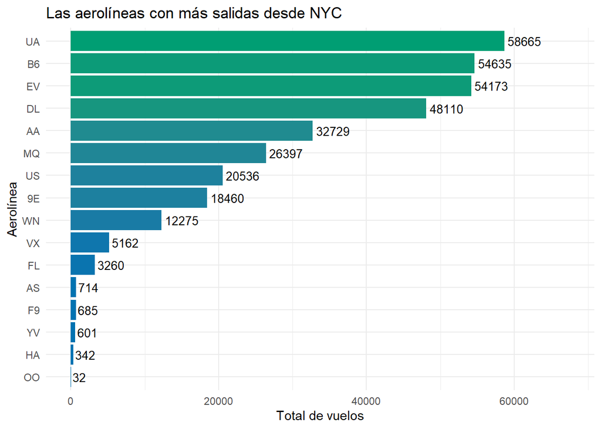

```r
#graficamos en ggplot2 la cantidad de vuelos por aerolínea
salida_frec_enNYC <- vuelos %>%
  filter(origin %in% c("LGA","EWR","JFK")) %>% #seleccionamos los aeropuertos de nyc
  group_by(carrier) %>% #tomamos las aerolíneas
  summarise(total_vuelos = n()) %>% #contamos el total de vuelos
  arrange(desc(total_vuelos)) %>%
  slice_max(total_vuelos, n = 16)  # Top 16 aerolíneas
#pedimos info de 16 aerolineas nada más en la gráfica
ggplot(salida_frec_enNYC, aes(x = reorder(carrier, total_vuelos), y = total_vuelos)) +
  geom_col(aes(fill = total_vuelos)) +
  geom_text(aes(label = total_vuelos),
            hjust = -0.1, size = 3.5) +
  coord_flip() +
  scale_fill_gradient(low = "#0072B2", high = "#009E73") + #colores usados
  labs(x = "Aerolínea", y = "Total de vuelos", #cota del eje x y y
       title = "Las aerolíneas con más salidas desde NYC") + #título del grafico
  theme_minimal() +
  theme(legend.position = "none") +
  ylim(0, max(salida_frec_enNYC$total_vuelos) * 1.15)  # espacio para etiquetas
```

Ahora en SQL:

```r
#hacemos lo mismo en sql
#casi es lo mismo que dplyr con sus filtros
#seleccionamos carrier para aerolíneas
#count hace el conteo de sus vuelos
#usa la data de vuelos.db
#seleccionamos el origen de los vuelos de ny por sus aeropuertos principales
#ordena los vuelos de forma descendente
vuelos_nyc_query <- "
  SELECT
    carrier,
    COUNT(*) AS total_vuelos
  FROM flights
  WHERE origin IN ('JFK', 'LGA', 'EWR')
  GROUP BY carrier
  ORDER BY total_vuelos DESC
"

frec_aerolineas_nyc <- dbGetQuery(con, vuelos_nyc_query)
frec_aerolineas_nyc
```

```
   carrier total_vuelos
1       UA        58665
2       B6        54635
3       EV        54173
4       DL        48110
5       AA        32729
6       MQ        26397
7       US        20536
8       9E        18460
9       WN        12275
10      VX         5162
11      FL         3260
12      AS          714
13      F9          685
14      YV          601
15      HA          342
16      OO           32
```

## 7. ¿Cómo varía el retraso de los vuelos según el fabricante de la aeronave?

Para responder necesitamos analizar si el retraso de los vuelos cambia dependiendo del fabricante del avión utilizado, para ello

- Utilizaremos las tablas `vuelos` y `aviones`
- Las uniremos mediante la variable `tailnum`
- Agruparemos por fabricante
- Calcularemos el retraso promedio de salida

```r
library(skimr)
```

```r
vuelos <- dbGetQuery( con,"SELECT * FROM flights")
aviones <- dbGetQuery(con,"SELECT * FROM planes")
```

Exploramos la estructura de los datos

```r
vuelos |> skim()
```

Data summary

| Name | vuelos |
| --- | --- |
| Number of rows | 336776 |
| Number of columns | 19 |
| _______________________ |  |
| Column type frequency: |  |
| character | 4 |
| numeric | 15 |
| ________________________ |  |
| Group variables | None |

**Variable type: character**

| skim_variable | n_missing | complete_rate | min | max | empty | n_unique | whitespace |
| --- | --- | --- | --- | --- | --- | --- | --- |
| carrier | 0 | 1.00 | 2 | 2 | 0 | 16 | 0 |
| tailnum | 2512 | 0.99 | 5 | 6 | 0 | 4043 | 0 |
| origin | 0 | 1.00 | 3 | 3 | 0 | 3 | 0 |
| dest | 0 | 1.00 | 3 | 3 | 0 | 105 | 0 |

**Variable type: numeric**

| skim_variable | n_missing | complete_rate | mean | sd | p0 | p25 | p50 | p75 | p100 | hist |
| --- | --- | --- | --- | --- | --- | --- | --- | --- | --- | --- |
| year | 0 | 1.00 | 2.013000e+03 | 0.00 | 2013 | 2013 | 2013 | 2013 | 2013 | ▁▁▇▁▁ |
| month | 0 | 1.00 | 6.550000e+00 | 3.41 | 1 | 4 | 7 | 10 | 12 | ▇▆▆▆▇ |
| day | 0 | 1.00 | 1.571000e+01 | 8.77 | 1 | 8 | 16 | 23 | 31 | ▇▇▇▇▆ |
| dep_time | 8255 | 0.98 | 1.349110e+03 | 488.28 | 1 | 907 | 1401 | 1744 | 2400 | ▁▇▆▇▃ |
| sched_dep_time | 0 | 1.00 | 1.344250e+03 | 467.34 | 106 | 906 | 1359 | 1729 | 2359 | ▁▇▇▇▃ |
| dep_delay | 8255 | 0.98 | 1.264000e+01 | 40.21 | -43 | -5 | -2 | 11 | 1301 | ▇▁▁▁▁ |
| arr_time | 8713 | 0.97 | 1.502050e+03 | 533.26 | 1 | 1104 | 1535 | 1940 | 2400 | ▁▃▇▇▇ |
| sched_arr_time | 0 | 1.00 | 1.536380e+03 | 497.46 | 1 | 1124 | 1556 | 1945 | 2359 | ▁▃▇▇▇ |
| arr_delay | 9430 | 0.97 | 6.900000e+00 | 44.63 | -86 | -17 | -5 | 14 | 1272 | ▇▁▁▁▁ |
| flight | 0 | 1.00 | 1.971920e+03 | 1632.47 | 1 | 553 | 1496 | 3465 | 8500 | ▇▃▃▁▁ |
| air_time | 9430 | 0.97 | 1.506900e+02 | 93.69 | 20 | 82 | 129 | 192 | 695 | ▇▂▂▁▁ |
| distance | 0 | 1.00 | 1.039910e+03 | 733.23 | 17 | 502 | 872 | 1389 | 4983 | ▇▃▂▁▁ |
| hour | 0 | 1.00 | 1.318000e+01 | 4.66 | 1 | 9 | 13 | 17 | 23 | ▁▇▇▇▅ |
| minute | 0 | 1.00 | 2.623000e+01 | 19.30 | 0 | 8 | 29 | 44 | 59 | ▇▃▆▃▅ |
| time_hour | 0 | 1.00 | 1.372843e+09 | 9009993.09 | 1357034400 | 1365094800 | 1372860000 | 1380625200 | 1388548800 | ▇▇▇▇▇ |

```r
aviones |> skim()
```

Data summary

| Name | aviones |
| --- | --- |
| Number of rows | 3322 |
| Number of columns | 9 |
| _______________________ |  |
| Column type frequency: |  |
| character | 5 |
| numeric | 4 |
| ________________________ |  |
| Group variables | None |

**Variable type: character**

| skim_variable | n_missing | complete_rate | min | max | empty | n_unique | whitespace |
| --- | --- | --- | --- | --- | --- | --- | --- |
| tailnum | 0 | 1 | 5 | 6 | 0 | 3322 | 0 |
| type | 0 | 1 | 10 | 24 | 0 | 3 | 0 |
| manufacturer | 0 | 1 | 4 | 29 | 0 | 35 | 0 |
| model | 0 | 1 | 2 | 18 | 0 | 127 | 0 |
| engine | 0 | 1 | 7 | 13 | 0 | 6 | 0 |

**Variable type: numeric**

| skim_variable | n_missing | complete_rate | mean | sd | p0 | p25 | p50 | p75 | p100 | hist |
| --- | --- | --- | --- | --- | --- | --- | --- | --- | --- | --- |
| year | 70 | 0.98 | 2000.48 | 7.19 | 1956 | 1997.0 | 2001 | 2005 | 2013 | ▁▁▂▇▇ |
| engines | 0 | 1.00 | 2.00 | 0.12 | 1 | 2.0 | 2 | 2 | 4 | ▁▇▁▁▁ |
| seats | 0 | 1.00 | 154.32 | 73.65 | 2 | 140.0 | 149 | 182 | 450 | ▂▇▃▁▁ |
| speed | 3299 | 0.01 | 236.78 | 149.76 | 90 | 107.5 | 162 | 432 | 432 | ▇▃▁▁▆ |

Revisamos los nombres de las variables

```r
names(vuelos)
```

```
 [1] "year"           "month"          "day"            "dep_time"
 [5] "sched_dep_time" "dep_delay"      "arr_time"       "sched_arr_time"
 [9] "arr_delay"      "carrier"        "flight"         "tailnum"
[13] "origin"         "dest"           "air_time"       "distance"
[17] "hour"           "minute"         "time_hour"
```

```r
names(aviones)
```

```
[1] "tailnum"      "year"         "type"         "manufacturer" "model"
[6] "engines"      "seats"        "speed"        "engine"
```

Unimos las tablas mediante la variable `tailnum`

```r
vuelos_fabricante <- vuelos %>%
inner_join(aviones,by="tailnum")
```

Vemos como quedó

```r
vuelos_fabricante |> skim()
```

Data summary

| Name | vuelos_fabricante |
| --- | --- |
| Number of rows | 284170 |
| Number of columns | 27 |
| _______________________ |  |
| Column type frequency: |  |
| character | 8 |
| numeric | 19 |
| ________________________ |  |
| Group variables | None |

**Variable type: character**

| skim_variable | n_missing | complete_rate | min | max | empty | n_unique | whitespace |
| --- | --- | --- | --- | --- | --- | --- | --- |
| carrier | 0 | 1 | 2 | 2 | 0 | 16 | 0 |
| tailnum | 0 | 1 | 5 | 6 | 0 | 3322 | 0 |
| origin | 0 | 1 | 3 | 3 | 0 | 3 | 0 |
| dest | 0 | 1 | 3 | 3 | 0 | 104 | 0 |
| type | 0 | 1 | 10 | 24 | 0 | 3 | 0 |
| manufacturer | 0 | 1 | 4 | 29 | 0 | 35 | 0 |
| model | 0 | 1 | 2 | 18 | 0 | 127 | 0 |
| engine | 0 | 1 | 7 | 13 | 0 | 6 | 0 |

**Variable type: numeric**

| skim_variable | n_missing | complete_rate | mean | sd | p0 | p25 | p50 | p75 | p100 | hist |
| --- | --- | --- | --- | --- | --- | --- | --- | --- | --- | --- |
| year.x | 0 | 1.00 | 2.013000e+03 | 0.00 | 2013 | 2013 | 2013.0 | 2013 | 2013 | ▁▁▇▁▁ |
| month | 0 | 1.00 | 6.570000e+00 | 3.41 | 1 | 4 | 7.0 | 10 | 12 | ▇▆▆▆▇ |
| day | 0 | 1.00 | 1.571000e+01 | 8.77 | 1 | 8 | 16.0 | 23 | 31 | ▇▇▇▇▆ |
| dep_time | 4199 | 0.99 | 1.350340e+03 | 493.58 | 1 | 905 | 1358.0 | 1752 | 2400 | ▁▇▆▇▃ |
| sched_dep_time | 0 | 1.00 | 1.344430e+03 | 471.73 | 500 | 905 | 1358.5 | 1730 | 2359 | ▇▆▇▇▃ |
| dep_delay | 4199 | 0.99 | 1.318000e+01 | 40.58 | -43 | -5 | -1.0 | 11 | 1301 | ▇▁▁▁▁ |
| arr_time | 4551 | 0.98 | 1.494710e+03 | 542.93 | 1 | 1059 | 1529.0 | 1942 | 2400 | ▁▃▇▇▇ |
| sched_arr_time | 0 | 1.00 | 1.530540e+03 | 506.81 | 1 | 1119 | 1553.0 | 1946 | 2359 | ▁▃▇▇▇ |
| arr_delay | 5153 | 0.98 | 7.050000e+00 | 44.95 | -86 | -17 | -5.0 | 14 | 1272 | ▇▁▁▁▁ |
| flight | 0 | 1.00 | 1.882830e+03 | 1636.17 | 1 | 511 | 1381.0 | 3318 | 8500 | ▇▂▃▁▁ |
| air_time | 5153 | 0.98 | 1.538100e+02 | 97.15 | 20 | 83 | 131.0 | 197 | 695 | ▇▂▂▁▁ |
| distance | 0 | 1.00 | 1.068650e+03 | 761.50 | 80 | 529 | 937.0 | 1416 | 4983 | ▇▃▂▁▁ |
| hour | 0 | 1.00 | 1.318000e+01 | 4.70 | 5 | 9 | 13.0 | 17 | 23 | ▇▆▆▇▃ |
| minute | 0 | 1.00 | 2.607000e+01 | 19.32 | 0 | 7 | 29.0 | 43 | 59 | ▇▃▇▃▅ |
| time_hour | 0 | 1.00 | 1.372898e+09 | 8997352.34 | 1357034400 | 1365174000 | 1372942800.0 | 1380661200 | 1388548800 | ▇▇▇▇▇ |
| year.y | 5306 | 0.98 | 2.001400e+03 | 6.39 | 1956 | 1999 | 2002.0 | 2006 | 2013 | ▁▁▁▆▇ |
| engines | 0 | 1.00 | 1.990000e+00 | 0.10 | 1 | 2 | 2.0 | 2 | 4 | ▁▇▁▁▁ |
| seats | 0 | 1.00 | 1.367200e+02 | 71.80 | 2 | 55 | 149.0 | 189 | 450 | ▆▇▆▁▁ |
| speed | 283207 | 0.00 | 1.507900e+02 | 95.14 | 90 | 105 | 126.0 | 127 | 432 | ▇▁▁▁▁ |

Ahora queremos analizar el retraso promedio según el fabricante y mostrando los resultados:

```r
retrasos_fabricante <- vuelos_fabricante %>%

filter(
!is.na(dep_delay),
!is.na(manufacturer)
) %>%

group_by(manufacturer) %>%

summarise(
RetrasoPromedio=mean(
dep_delay,
na.rm=TRUE
),

RetrasoMediano=median(
dep_delay,
na.rm=TRUE
),

TotalVuelos=n()
) %>%

ungroup() %>%

arrange(
desc(RetrasoPromedio)
)
retrasos_fabricante
```

```
# A tibble: 35 × 4
   manufacturer       RetrasoPromedio RetrasoMediano TotalVuelos
   <chr>                        <dbl>          <dbl>       <int>
 1 AGUSTA SPA                    32.5            2            31
 2 FRIEDEMANN JON                20.7           -2            59
 3 AVIAT AIRCRAFT INC            20.6           -2.5          18
 4 CANADAIR                      18.3           -3          1492
 5 BOMBARDIER INC                17.5           -2         27588
 6 EMBRAER                       16.8           -2         63783
 7 LAMBERT RICHARD               15.5           -4            54
 8 BELL                          14.3           -3            64
 9 BEECH                         14.1            0            46
10 BARKER JACK L                 13.8            0           250
# ℹ 25 more rows
```

Obtendremos los fabricantes con mayor retraso promedio:

```r
top_fabricantes <- retrasos_fabricante %>%

top_n(
10,
wt=RetrasoPromedio
) %>%

arrange(
desc(RetrasoPromedio)
) %>%

mutate(
ranking=10:1
)

top_fabricantes
```

```
# A tibble: 10 × 5
   manufacturer       RetrasoPromedio RetrasoMediano TotalVuelos ranking
   <chr>                        <dbl>          <dbl>       <int>   <int>
 1 AGUSTA SPA                    32.5            2            31      10
 2 FRIEDEMANN JON                20.7           -2            59       9
 3 AVIAT AIRCRAFT INC            20.6           -2.5          18       8
 4 CANADAIR                      18.3           -3          1492       7
 5 BOMBARDIER INC                17.5           -2         27588       6
 6 EMBRAER                       16.8           -2         63783       5
 7 LAMBERT RICHARD               15.5           -4            54       4
 8 BELL                          14.3           -3            64       3
 9 BEECH                         14.1            0            46       2
10 BARKER JACK L                 13.8            0           250       1
```

Realizamos una gráfica para entender y visualizar mejor los resultados

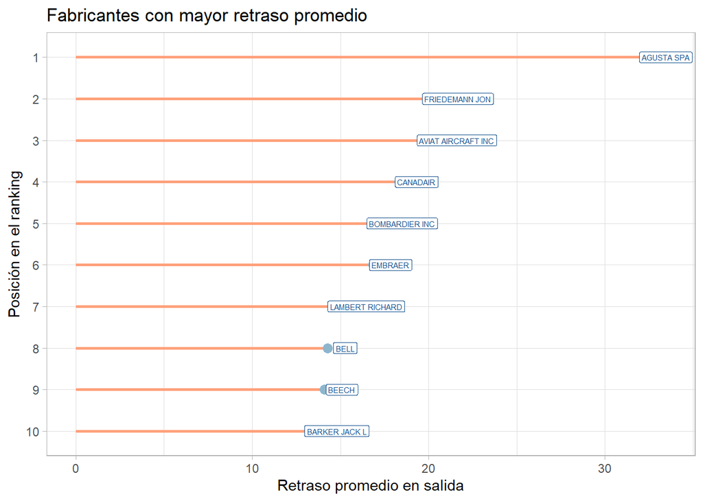

```r
top_fabricantes %>%

ggplot() +

geom_segment(
aes(
x=0,
y=ranking,
xend=RetrasoPromedio,
yend=ranking
),
linewidth=1,
color="lightsalmon"
)+

geom_point(
aes(
y=ranking,
x=RetrasoPromedio
),
color="lightskyblue3",
size=3
)+

geom_label(
aes(
y=ranking,
x=RetrasoPromedio+1,
label=manufacturer
),
color="dodgerblue4",
size=2
)+

scale_y_discrete(
limits=factor(10:1)
)+

theme_light() +

xlab(
"Retraso promedio en salida"
)+

ylab(
"Posición en el ranking"
)+

ggtitle(
"Fabricantes con mayor retraso promedio"
)
```

- Solución utilizando SQL

Ahora realizamos el mismo análisis utilizando SQL

```r
query_sql <- dbGetQuery(

con,

"SELECT
a.manufacturer,
AVG(v.dep_delay) AS retraso_promedio,
COUNT(*) AS total_vuelos

FROM flights v

INNER JOIN planes a
ON v.tailnum=a.tailnum

WHERE v.dep_delay IS NOT NULL
AND a.manufacturer IS NOT NULL

GROUP BY a.manufacturer

ORDER BY retraso_promedio DESC"

)

query_sql
```

```
                    manufacturer retraso_promedio total_vuelos
1                     AGUSTA SPA       32.4516129           31
2                 FRIEDEMANN JON       20.6610169           59
3             AVIAT AIRCRAFT INC       20.6111111           18
4                       CANADAIR       18.3250670         1492
5                 BOMBARDIER INC       17.4969552        27588
6                        EMBRAER       16.8427951        63783
7                LAMBERT RICHARD       15.4629630           54
8                           BELL       14.2656250           64
9                          BEECH       14.0869565           46
10                 BARKER JACK L       13.7920000          250
11        ROBINSON HELICOPTER CO       12.8327402          281
12 MCDONNELL DOUGLAS CORPORATION       12.5611511         1251
13 MCDONNELL DOUGLAS AIRCRAFT CO       12.3324684         8864
14                        BOEING       11.6934831        82524
```

[output cut: 21 more lines]

Los resultados muestran que existen diferencias entre fabricantes ya que algunos presentan retrasos promedio considerablemente mayores que otros, esto sugiere que el comportamiento de los retrasos no es uniforme entre los distintos tipos de aeronaves utilizadas, sin embargo, esta diferencia no necesariamente implica una relación causal directa entre fabricante y retraso, ya que pueden intervenir otros factores como rutas específicas, condiciones meteorológicas, antigüedad de la aeronave, frecuencia de uso o políticas operativas de cada aerolínea.

## 8. ¿Los aviones más antiguos tienen más retrasos?

Para responder necesitamos analizar si la antigüedad de un avión tiene relación con los retrasos de salida de los vuelos, para ello:

- Utilizaremos las tablas `vuelos` y `aviones`
- Las uniremos mediante la variable `tailnum`
- Calcularemos la antigüedad del avión
- Agruparemos por antigüedad
- Calcularemos el retraso promedio

Unimos las tablas con la variable `tailnum`

```r
vuelos_antiguedad <- vuelos %>%

inner_join(aviones,by="tailnum")
```

Exploramos la nueva estructura

```r
vuelos_antiguedad |> skim()
```

Data summary

| Name | vuelos_antiguedad |
| --- | --- |
| Number of rows | 284170 |
| Number of columns | 27 |
| _______________________ |  |
| Column type frequency: |  |
| character | 8 |
| numeric | 19 |
| ________________________ |  |
| Group variables | None |

**Variable type: character**

| skim_variable | n_missing | complete_rate | min | max | empty | n_unique | whitespace |
| --- | --- | --- | --- | --- | --- | --- | --- |
| carrier | 0 | 1 | 2 | 2 | 0 | 16 | 0 |
| tailnum | 0 | 1 | 5 | 6 | 0 | 3322 | 0 |
| origin | 0 | 1 | 3 | 3 | 0 | 3 | 0 |
| dest | 0 | 1 | 3 | 3 | 0 | 104 | 0 |
| type | 0 | 1 | 10 | 24 | 0 | 3 | 0 |
| manufacturer | 0 | 1 | 4 | 29 | 0 | 35 | 0 |
| model | 0 | 1 | 2 | 18 | 0 | 127 | 0 |
| engine | 0 | 1 | 7 | 13 | 0 | 6 | 0 |

**Variable type: numeric**

| skim_variable | n_missing | complete_rate | mean | sd | p0 | p25 | p50 | p75 | p100 | hist |
| --- | --- | --- | --- | --- | --- | --- | --- | --- | --- | --- |
| year.x | 0 | 1.00 | 2.013000e+03 | 0.00 | 2013 | 2013 | 2013.0 | 2013 | 2013 | ▁▁▇▁▁ |
| month | 0 | 1.00 | 6.570000e+00 | 3.41 | 1 | 4 | 7.0 | 10 | 12 | ▇▆▆▆▇ |
| day | 0 | 1.00 | 1.571000e+01 | 8.77 | 1 | 8 | 16.0 | 23 | 31 | ▇▇▇▇▆ |
| dep_time | 4199 | 0.99 | 1.350340e+03 | 493.58 | 1 | 905 | 1358.0 | 1752 | 2400 | ▁▇▆▇▃ |
| sched_dep_time | 0 | 1.00 | 1.344430e+03 | 471.73 | 500 | 905 | 1358.5 | 1730 | 2359 | ▇▆▇▇▃ |
| dep_delay | 4199 | 0.99 | 1.318000e+01 | 40.58 | -43 | -5 | -1.0 | 11 | 1301 | ▇▁▁▁▁ |
| arr_time | 4551 | 0.98 | 1.494710e+03 | 542.93 | 1 | 1059 | 1529.0 | 1942 | 2400 | ▁▃▇▇▇ |
| sched_arr_time | 0 | 1.00 | 1.530540e+03 | 506.81 | 1 | 1119 | 1553.0 | 1946 | 2359 | ▁▃▇▇▇ |
| arr_delay | 5153 | 0.98 | 7.050000e+00 | 44.95 | -86 | -17 | -5.0 | 14 | 1272 | ▇▁▁▁▁ |
| flight | 0 | 1.00 | 1.882830e+03 | 1636.17 | 1 | 511 | 1381.0 | 3318 | 8500 | ▇▂▃▁▁ |
| air_time | 5153 | 0.98 | 1.538100e+02 | 97.15 | 20 | 83 | 131.0 | 197 | 695 | ▇▂▂▁▁ |
| distance | 0 | 1.00 | 1.068650e+03 | 761.50 | 80 | 529 | 937.0 | 1416 | 4983 | ▇▃▂▁▁ |
| hour | 0 | 1.00 | 1.318000e+01 | 4.70 | 5 | 9 | 13.0 | 17 | 23 | ▇▆▆▇▃ |
| minute | 0 | 1.00 | 2.607000e+01 | 19.32 | 0 | 7 | 29.0 | 43 | 59 | ▇▃▇▃▅ |
| time_hour | 0 | 1.00 | 1.372898e+09 | 8997352.34 | 1357034400 | 1365174000 | 1372942800.0 | 1380661200 | 1388548800 | ▇▇▇▇▇ |
| year.y | 5306 | 0.98 | 2.001400e+03 | 6.39 | 1956 | 1999 | 2002.0 | 2006 | 2013 | ▁▁▁▆▇ |
| engines | 0 | 1.00 | 1.990000e+00 | 0.10 | 1 | 2 | 2.0 | 2 | 4 | ▁▇▁▁▁ |
| seats | 0 | 1.00 | 1.367200e+02 | 71.80 | 2 | 55 | 149.0 | 189 | 450 | ▆▇▆▁▁ |
| speed | 283207 | 0.00 | 1.507900e+02 | 95.14 | 90 | 105 | 126.0 | 127 | 432 | ▇▁▁▁▁ |

Calcularemos la antigüedad del avión, como los vuelos corresponden al año 2013, entonces

Antigüedad = 2013 − año de fabricación

```r
vuelos_antiguedad <- vuelos_antiguedad %>%

mutate(antiguedad=2013-year.y)
```

```r
aviones |> names()
```

```
[1] "tailnum"      "year"         "type"         "manufacturer" "model"
[6] "engines"      "seats"        "speed"        "engine"
```

Observamos la nueva variable creada

```r
vuelos_antiguedad |> skim()
```

Data summary

| Name | vuelos_antiguedad |
| --- | --- |
| Number of rows | 284170 |
| Number of columns | 28 |
| _______________________ |  |
| Column type frequency: |  |
| character | 8 |
| numeric | 20 |
| ________________________ |  |
| Group variables | None |

**Variable type: character**

| skim_variable | n_missing | complete_rate | min | max | empty | n_unique | whitespace |
| --- | --- | --- | --- | --- | --- | --- | --- |
| carrier | 0 | 1 | 2 | 2 | 0 | 16 | 0 |
| tailnum | 0 | 1 | 5 | 6 | 0 | 3322 | 0 |
| origin | 0 | 1 | 3 | 3 | 0 | 3 | 0 |
| dest | 0 | 1 | 3 | 3 | 0 | 104 | 0 |
| type | 0 | 1 | 10 | 24 | 0 | 3 | 0 |
| manufacturer | 0 | 1 | 4 | 29 | 0 | 35 | 0 |
| model | 0 | 1 | 2 | 18 | 0 | 127 | 0 |
| engine | 0 | 1 | 7 | 13 | 0 | 6 | 0 |

**Variable type: numeric**

| skim_variable | n_missing | complete_rate | mean | sd | p0 | p25 | p50 | p75 | p100 | hist |
| --- | --- | --- | --- | --- | --- | --- | --- | --- | --- | --- |
| year.x | 0 | 1.00 | 2.013000e+03 | 0.00 | 2013 | 2013 | 2013.0 | 2013 | 2013 | ▁▁▇▁▁ |
| month | 0 | 1.00 | 6.570000e+00 | 3.41 | 1 | 4 | 7.0 | 10 | 12 | ▇▆▆▆▇ |
| day | 0 | 1.00 | 1.571000e+01 | 8.77 | 1 | 8 | 16.0 | 23 | 31 | ▇▇▇▇▆ |
| dep_time | 4199 | 0.99 | 1.350340e+03 | 493.58 | 1 | 905 | 1358.0 | 1752 | 2400 | ▁▇▆▇▃ |
| sched_dep_time | 0 | 1.00 | 1.344430e+03 | 471.73 | 500 | 905 | 1358.5 | 1730 | 2359 | ▇▆▇▇▃ |
| dep_delay | 4199 | 0.99 | 1.318000e+01 | 40.58 | -43 | -5 | -1.0 | 11 | 1301 | ▇▁▁▁▁ |
| arr_time | 4551 | 0.98 | 1.494710e+03 | 542.93 | 1 | 1059 | 1529.0 | 1942 | 2400 | ▁▃▇▇▇ |
| sched_arr_time | 0 | 1.00 | 1.530540e+03 | 506.81 | 1 | 1119 | 1553.0 | 1946 | 2359 | ▁▃▇▇▇ |
| arr_delay | 5153 | 0.98 | 7.050000e+00 | 44.95 | -86 | -17 | -5.0 | 14 | 1272 | ▇▁▁▁▁ |
| flight | 0 | 1.00 | 1.882830e+03 | 1636.17 | 1 | 511 | 1381.0 | 3318 | 8500 | ▇▂▃▁▁ |
| air_time | 5153 | 0.98 | 1.538100e+02 | 97.15 | 20 | 83 | 131.0 | 197 | 695 | ▇▂▂▁▁ |
| distance | 0 | 1.00 | 1.068650e+03 | 761.50 | 80 | 529 | 937.0 | 1416 | 4983 | ▇▃▂▁▁ |
| hour | 0 | 1.00 | 1.318000e+01 | 4.70 | 5 | 9 | 13.0 | 17 | 23 | ▇▆▆▇▃ |
| minute | 0 | 1.00 | 2.607000e+01 | 19.32 | 0 | 7 | 29.0 | 43 | 59 | ▇▃▇▃▅ |
| time_hour | 0 | 1.00 | 1.372898e+09 | 8997352.34 | 1357034400 | 1365174000 | 1372942800.0 | 1380661200 | 1388548800 | ▇▇▇▇▇ |
| year.y | 5306 | 0.98 | 2.001400e+03 | 6.39 | 1956 | 1999 | 2002.0 | 2006 | 2013 | ▁▁▁▆▇ |
| engines | 0 | 1.00 | 1.990000e+00 | 0.10 | 1 | 2 | 2.0 | 2 | 4 | ▁▇▁▁▁ |
| seats | 0 | 1.00 | 1.367200e+02 | 71.80 | 2 | 55 | 149.0 | 189 | 450 | ▆▇▆▁▁ |
| speed | 283207 | 0.00 | 1.507900e+02 | 95.14 | 90 | 105 | 126.0 | 127 | 432 | ▇▁▁▁▁ |
| antiguedad | 5306 | 0.98 | 1.160000e+01 | 6.39 | 0 | 7 | 11.0 | 14 | 57 | ▇▆▁▁▁ |

Ahora analizaremos el retraso promedio según antigüedad

```r
retrasos_antiguedad <- vuelos_antiguedad %>%

filter(
!is.na(dep_delay),
!is.na(antiguedad),
antiguedad>=0
) %>%

group_by(
antiguedad
) %>%

summarise(

RetrasoPromedio=mean(
dep_delay,
na.rm=TRUE
),

RetrasoMediano=median(
dep_delay,
na.rm=TRUE
),

TotalVuelos=n()

) %>%

ungroup() %>%

arrange(
desc(antiguedad)
)

retrasos_antiguedad
```

```
# A tibble: 46 × 4
   antiguedad RetrasoPromedio RetrasoMediano TotalVuelos
        <dbl>           <dbl>          <dbl>       <int>
 1         57            5.95            1            22
 2         54            9.93           -4           112
 3         50            8.08           -2            51
 4         48           -4              -6.5           4
 5         46           10.3            -1            22
 6         45           10.5            -4            41
 7         41           17.6             0            24
 8         40            6.18            2            22
 9         39            9.37           -3            93
10         38           13.0            -3            91
# ℹ 36 more rows
```

Realizamos una gráfica para visualizar y entender mejor la relacion

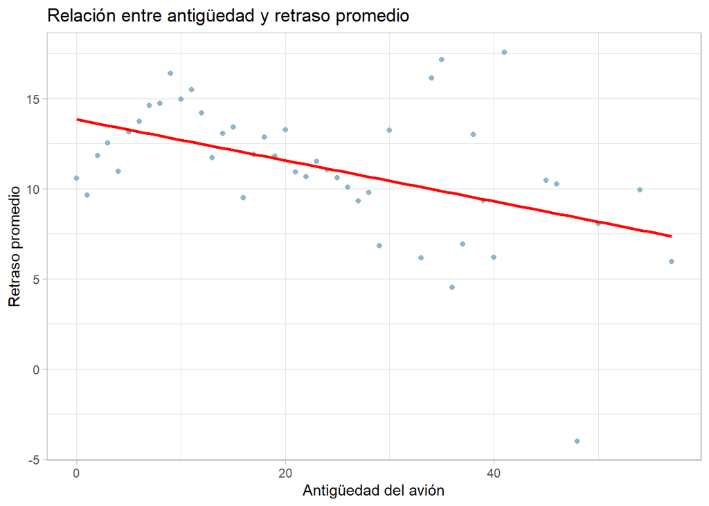

```r
retrasos_antiguedad %>%

ggplot(
aes(
x=antiguedad,
y=RetrasoPromedio
)
)+

geom_point(
color="lightskyblue3"
)+

geom_smooth(
method="lm",
se=FALSE,
color="red"
)+

theme_light()+

xlab(
"Antigüedad del avión"
)+

ylab(
"Retraso promedio"
)+

ggtitle(
"Relación entre antigüedad y retraso promedio"
)
```

- Solucion utilizando SQL

Ahora realizamos el mismo análisis utilizando SQL

```r
query_sql <- dbGetQuery(

con,

"SELECT

(2013-a.year) AS antiguedad,

AVG(v.dep_delay) AS retraso_promedio,

COUNT(*) AS total_vuelos

FROM flights v

INNER JOIN planes a

ON v.tailnum=a.tailnum

WHERE v.dep_delay IS NOT NULL
AND a.year IS NOT NULL
AND (2013-a.year)>=0

GROUP BY antiguedad

ORDER BY antiguedad DESC"

)

query_sql
```

```
   antiguedad retraso_promedio total_vuelos
1          57         5.954545           22
2          54         9.928571          112
3          50         8.078431           51
4          48        -4.000000            4
5          46        10.272727           22
6          45        10.463415           41
7          41        17.583333           24
8          40         6.181818           22
9          39         9.365591           93
10         38        13.021978           91
11         37         6.925430          523
12         36         4.514286          175
13         35        17.166667           24
14         34        16.142857           63
```

[output cut: 32 more lines]

El análisis refleja que si existe relacion entre la antigueda de los aviones y los retrasos de salida,la gráfica de dispersión junto con la línea de tendencia permite observar si existe una relación entre ambas variables y analizar si los aviones más antiguos presentan mayores retrasos promedio.

## 9. ¿Qué modelos de aviones se utilizan con mayor frecuencia en vuelos desde NYC?

Para responder esta pregunta necesitamos identificar cuáles modelos de aeronaves aparecen con mayor frecuencia en los vuelos que salieron de NYC durante 2013, para ello

- Utilizaremos las tablas `vuelos` y `aviones`
- Las uniremos mediante la variable `tailnum`
- Agruparemos por modelo de avión
- Contaremos cuántos vuelos realizó cada modelo

```r
vuelos_modelos <- vuelos %>%

inner_join(aviones,by="tailnum")
```

Observamos la nueva estructura después de unir

```r
vuelos_modelos |> skim()
```

Data summary

| Name | vuelos_modelos |
| --- | --- |
| Number of rows | 284170 |
| Number of columns | 27 |
| _______________________ |  |
| Column type frequency: |  |
| character | 8 |
| numeric | 19 |
| ________________________ |  |
| Group variables | None |

**Variable type: character**

| skim_variable | n_missing | complete_rate | min | max | empty | n_unique | whitespace |
| --- | --- | --- | --- | --- | --- | --- | --- |
| carrier | 0 | 1 | 2 | 2 | 0 | 16 | 0 |
| tailnum | 0 | 1 | 5 | 6 | 0 | 3322 | 0 |
| origin | 0 | 1 | 3 | 3 | 0 | 3 | 0 |
| dest | 0 | 1 | 3 | 3 | 0 | 104 | 0 |
| type | 0 | 1 | 10 | 24 | 0 | 3 | 0 |
| manufacturer | 0 | 1 | 4 | 29 | 0 | 35 | 0 |
| model | 0 | 1 | 2 | 18 | 0 | 127 | 0 |
| engine | 0 | 1 | 7 | 13 | 0 | 6 | 0 |

**Variable type: numeric**

| skim_variable | n_missing | complete_rate | mean | sd | p0 | p25 | p50 | p75 | p100 | hist |
| --- | --- | --- | --- | --- | --- | --- | --- | --- | --- | --- |
| year.x | 0 | 1.00 | 2.013000e+03 | 0.00 | 2013 | 2013 | 2013.0 | 2013 | 2013 | ▁▁▇▁▁ |
| month | 0 | 1.00 | 6.570000e+00 | 3.41 | 1 | 4 | 7.0 | 10 | 12 | ▇▆▆▆▇ |
| day | 0 | 1.00 | 1.571000e+01 | 8.77 | 1 | 8 | 16.0 | 23 | 31 | ▇▇▇▇▆ |
| dep_time | 4199 | 0.99 | 1.350340e+03 | 493.58 | 1 | 905 | 1358.0 | 1752 | 2400 | ▁▇▆▇▃ |
| sched_dep_time | 0 | 1.00 | 1.344430e+03 | 471.73 | 500 | 905 | 1358.5 | 1730 | 2359 | ▇▆▇▇▃ |
| dep_delay | 4199 | 0.99 | 1.318000e+01 | 40.58 | -43 | -5 | -1.0 | 11 | 1301 | ▇▁▁▁▁ |
| arr_time | 4551 | 0.98 | 1.494710e+03 | 542.93 | 1 | 1059 | 1529.0 | 1942 | 2400 | ▁▃▇▇▇ |
| sched_arr_time | 0 | 1.00 | 1.530540e+03 | 506.81 | 1 | 1119 | 1553.0 | 1946 | 2359 | ▁▃▇▇▇ |
| arr_delay | 5153 | 0.98 | 7.050000e+00 | 44.95 | -86 | -17 | -5.0 | 14 | 1272 | ▇▁▁▁▁ |
| flight | 0 | 1.00 | 1.882830e+03 | 1636.17 | 1 | 511 | 1381.0 | 3318 | 8500 | ▇▂▃▁▁ |
| air_time | 5153 | 0.98 | 1.538100e+02 | 97.15 | 20 | 83 | 131.0 | 197 | 695 | ▇▂▂▁▁ |
| distance | 0 | 1.00 | 1.068650e+03 | 761.50 | 80 | 529 | 937.0 | 1416 | 4983 | ▇▃▂▁▁ |
| hour | 0 | 1.00 | 1.318000e+01 | 4.70 | 5 | 9 | 13.0 | 17 | 23 | ▇▆▆▇▃ |
| minute | 0 | 1.00 | 2.607000e+01 | 19.32 | 0 | 7 | 29.0 | 43 | 59 | ▇▃▇▃▅ |
| time_hour | 0 | 1.00 | 1.372898e+09 | 8997352.34 | 1357034400 | 1365174000 | 1372942800.0 | 1380661200 | 1388548800 | ▇▇▇▇▇ |
| year.y | 5306 | 0.98 | 2.001400e+03 | 6.39 | 1956 | 1999 | 2002.0 | 2006 | 2013 | ▁▁▁▆▇ |
| engines | 0 | 1.00 | 1.990000e+00 | 0.10 | 1 | 2 | 2.0 | 2 | 4 | ▁▇▁▁▁ |
| seats | 0 | 1.00 | 1.367200e+02 | 71.80 | 2 | 55 | 149.0 | 189 | 450 | ▆▇▆▁▁ |
| speed | 283207 | 0.00 | 1.507900e+02 | 95.14 | 90 | 105 | 126.0 | 127 | 432 | ▇▁▁▁▁ |

Ahora queremos conocer cuántos vuelos realizó cada modelo de avión

```r
modelos_frecuentes <- vuelos_modelos %>%

filter(!is.na(model)) %>%

group_by(model) %>%

summarise(
TotalVuelos=n()
) %>%

ungroup() %>%

arrange(desc(TotalVuelos))

modelos_frecuentes
```

```
# A tibble: 127 × 2
   model           TotalVuelos
   <chr>                 <int>
 1 A320-232              45831
 2 EMB-145LR             28027
 3 ERJ 190-100 IGW       23716
 4 EMB-145XR             14051
 5 737-824               13809
 6 CL-600-2D24           11807
 7 737-7H4               10389
 8 MD-88                 10191
 9 A319-114               9713
10 CL-600-2B19            9588
# ℹ 117 more rows
```

Ahora obtendremos únicamente los 10 modelos más utilizados. Visualizamos el top 10.

```r
top_modelos <- modelos_frecuentes %>%

top_n(
10,
wt=TotalVuelos
) %>%

arrange(desc(TotalVuelos)) %>%

mutate(
ranking=10:1
)

top_modelos
```

```
# A tibble: 10 × 3
   model           TotalVuelos ranking
   <chr>                 <int>   <int>
 1 A320-232              45831      10
 2 EMB-145LR             28027       9
 3 ERJ 190-100 IGW       23716       8
 4 EMB-145XR             14051       7
 5 737-824               13809       6
 6 CL-600-2D24           11807       5
 7 737-7H4               10389       4
 8 MD-88                 10191       3
 9 A319-114               9713       2
10 CL-600-2B19            9588       1
```

Realizamos una gráfica para entender mejor los resultados.

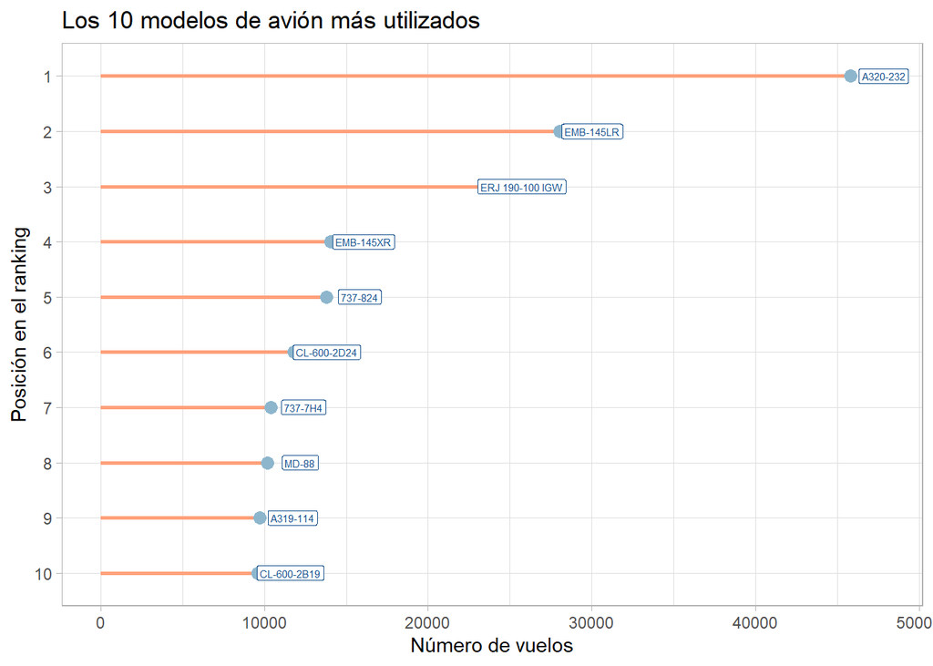

```r
top_modelos %>%

ggplot() +

geom_segment(
aes(
x=0,
y=ranking,
xend=TotalVuelos,
yend=ranking
),
linewidth=1,
color="lightsalmon"
)+

geom_point(
aes(
y=ranking,
x=TotalVuelos
),
color="lightskyblue3",
size=3
)+

geom_label(
aes(
y=ranking,
x=TotalVuelos+2000,
label=model
),
color="dodgerblue4",
size=2
)+

scale_y_discrete(
limits=factor(10:1)
)+

theme_light() +

xlab("Número de vuelos") +

ylab("Posición en el ranking") +

ggtitle(
"Los 10 modelos de avión más utilizados"
)
```

El análisis de los vuelos realizados desde NYC muestra que el modelo de avión más utilizado es el Airbus A320-232, seguido por aeronaves regionales como el Embraer EMB-145LR y el ERJ 190-100 IGW.

- Solución utilizando SQL

Ahora realizamos el mismo análisis utilizando sintaxis SQL

```r
query_sql <- dbGetQuery(

con,

"SELECT
a.model,
COUNT(*) AS total_vuelos

FROM flights v

INNER JOIN planes a
ON v.tailnum=a.tailnum

WHERE a.model IS NOT NULL

GROUP BY a.model

ORDER BY total_vuelos DESC"

)
```

Mostramos resultados.

```r
query_sql
```

```
                 model total_vuelos
1             A320-232        45831
2            EMB-145LR        28027
3      ERJ 190-100 IGW        23716
4            EMB-145XR        14051
5              737-824        13809
6          CL-600-2D24        11807
7              737-7H4        10389
8                MD-88        10191
9             A319-114         9713
10         CL-600-2B19         9588
11             757-222         9150
12             737-832         8735
13         CL-600-2C10         8471
14            A319-131         6546
```

[output cut: 113 more lines]

El análisis permite identificar cuáles modelos de aeronaves fueron utilizados con mayor frecuencia en los vuelos que salieron de NYC durante 2013, los resultados muestran cuáles aeronaves dominaron el tráfico aéreo y permiten comparar la frecuencia de uso entre distintos modelos. La gráfica facilita visualizar los modelos más utilizados y su diferencia respecto a los demás.

## 10. ¿Cuál es la distancia promedio de vuelo por aerolínea?

Contestando a la pregunta ¿Cual es la distancia promedio de vuelo por aerolinea? ( Con sintaxis sql)

```r
dbGetQuery(con, "SELECT * FROM airlines")
```

```
   carrier                        name
1       9E           Endeavor Air Inc.
2       AA      American Airlines Inc.
3       AS        Alaska Airlines Inc.
4       B6             JetBlue Airways
5       DL        Delta Air Lines Inc.
6       EV    ExpressJet Airlines Inc.
7       F9      Frontier Airlines Inc.
8       FL AirTran Airways Corporation
9       HA      Hawaiian Airlines Inc.
10      MQ                   Envoy Air
11      OO       SkyWest Airlines Inc.
12      UA       United Air Lines Inc.
13      US             US Airways Inc.
14      VX              Virgin America
15      WN      Southwest Airlines Co.
16      YV          Mesa Airlines Inc.
```

```r
dbGetQuery(con, "SELECT * FROM flights")
```

[output not shown]

[output cut: 15778 more lines]

```r
# Primero seleccionamos la columna de las aerolineas (carrier) y le sacamos el promedio al tiempo que estan en vuelo los aviones usando SELECT carrier, AVG(air_time) AS 'promedio_en_aire'

# Lo vamos a agrupar por aerolineas con GROUP BY carrier y vamos a ordenar los promedios de menor a mayor con ORDER BY promedio_en_aire
promedio_en_aire <- dbGetQuery(con,"SELECT carrier, AVG(distance) AS 'distancia_promedio_de_vuelo' FROM flights
                 GROUP BY carrier
                 ORDER BY distancia_promedio_de_vuelo")
promedio_en_aire
```

```
   carrier distancia_promedio_de_vuelo
1       YV                    375.0333
2       OO                    500.8125
3       9E                    530.2358
4       US                    553.4563
5       EV                    562.9917
6       MQ                    569.5327
7       FL                    664.8294
8       WN                    996.2691
9       B6                   1068.6215
10      DL                   1236.9012
11      AA                   1340.2360
12      UA                   1529.1149
13      F9                   1620.0000
14      AS                   2402.0000
15      VX                   2499.4822
16      HA                   4983.0000
```

Ahora con verbos dplyr:

```r
datos_vuelos <- dbGetQuery(con, "SELECT * FROM flights")
datos_vuelos
```

[output not shown]

[output cut: 15778 more lines]

```r
# Agrupamos por medio de la columna carrier
datos_vuelos |> group_by(carrier) |>
  # Sacamos el promedio de la columna distance
  summarize(distancia_promedio = mean(distance, na.rm = TRUE)) |>
  arrange(distancia_promedio)
```

```
# A tibble: 16 × 2
   carrier distancia_promedio
   <chr>                <dbl>
 1 YV                    375.
 2 OO                    501.
 3 9E                    530.
 4 US                    553.
 5 EV                    563.
 6 MQ                    570.
 7 FL                    665.
 8 WN                    996.
 9 B6                   1069.
10 DL                   1237.
11 AA                   1340.
12 UA                   1529.
13 F9                   1620
14 AS                   2402
15 VX                   2499.
16 HA                   4983
```

## 11. ¿Qué aeropuerto de NYC tuvo el mayor número de retrasos en la salida?

```r
dbGetQuery(con, "SELECT * FROM airlines")
```

```
   carrier                        name
1       9E           Endeavor Air Inc.
2       AA      American Airlines Inc.
3       AS        Alaska Airlines Inc.
4       B6             JetBlue Airways
5       DL        Delta Air Lines Inc.
6       EV    ExpressJet Airlines Inc.
7       F9      Frontier Airlines Inc.
8       FL AirTran Airways Corporation
9       HA      Hawaiian Airlines Inc.
10      MQ                   Envoy Air
11      OO       SkyWest Airlines Inc.
12      UA       United Air Lines Inc.
13      US             US Airways Inc.
14      VX              Virgin America
15      WN      Southwest Airlines Co.
16      YV          Mesa Airlines Inc.
```

```r
# Seleccionamos la columna del aeropuerto de origen (origin)

# Despues con la sintaxis COUNT(dep_delay) AS 'retrasos_salidas' estamos contando los los elementos que hay en la columna dep_delay

# Y junto con con WHERE dep_delay > 0 estamos contando solo los elementos que tengan un valor positivo, es decir, que hubo un retraso en la salida del vuelo

# Despues los agrupamos por el aeropuerto de origen
dbGetQuery(con, "SELECT origin, COUNT(dep_delay) AS 'numero_retrasos' FROM flights
           WHERE dep_delay > 0
           GROUP BY origin")
```

```
  origin numero_retrasos
1    EWR           52711
2    JFK           42031
3    LGA           33690
```

Contestando a la pregunta con sintaxis r:

```r
# Primero filtramos los valores de dep_delay positivos, pues estos respresentan los restrasos en las salidas
datos_vuelos |> dplyr::filter(dep_delay > 0) |>
  # Agrupamos por el aeropuerto  de origen
  group_by(origin) |>
  # Contamos cuantos vuelos tienen dep_delay > 0
  summarize(numero_retrasos = n()) |>
  arrange(desc(numero_retrasos))
```

```
# A tibble: 3 × 2
  origin numero_retrasos
  <chr>            <int>
1 EWR              52711
2 JFK              42031
3 LGA              33690
```

Aqui podemos ver que el aeropuerto con mayor numero de retrasos es EWR (Aeropuerto Internacional Libertad de Newark).

## 12. ¿Qué aeropuerto tuvo el menor tiempo promedio de taxi-out?

Con sintaxis sql:

```r
datos_aeropuertos <- dbGetQuery(con, "SELECT * FROM airports")
datos_aeropuertos
```

```
     faa                                                name      lat
1    04G                                   Lansdowne Airport 41.13047
2    06A                       Moton Field Municipal Airport 32.46057
3    06C                                 Schaumburg Regional 41.98934
4    06N                                     Randall Airport 41.43191
5    09J                               Jekyll Island Airport 31.07447
6    0A9                      Elizabethton Municipal Airport 36.37122
7    0G6                             Williams County Airport 41.46731
8    0G7                       Finger Lakes Regional Airport 42.88356
9    0P2                        Shoestring Aviation Airfield 39.79482
10   0S9                               Jefferson County Intl 48.05381
11   0W3                              Harford County Airport 39.56684
12   10C                                  Galt Field Airport 42.40289
13   17G                Port Bucyrus-Crawford County Airport 40.78156
14   19A                              Jackson County Airport 34.17586
```

[output cut: 2903 more lines]

```r
# Primero uniremos las tablas de vuelos y aeropuertos por medio de los datos que sean iguales en la columna "dest" de la tabla de vuelos y la columna "faa" de la tabla de aeropuertos

# Esto lo realizamos ya que queremos obtener una estimación del taxi-out por medio de la siguiente formula: (arr_time - air_time) - dep_time

# Pero si relaizamos esta operación en la tabla de vuelos obtendremos una gran cantidad de valores negaticos y esto se debe a que en el dataset muchos vuelos de Nueva York tienen como destino lugares con una zona horario diferente, lo que provoca problemas en los calculos debido a la diferencia de zona horario.

vuelos_por_zona_horaria <- datos_vuelos |>
  left_join(datos_aeropuertos, by = c("dest" = "faa")) |>
  # Filtramos los datos para no tomar NA's
  filter(!is.na(air_time), !is.na(dep_time), !is.na(arr_time)) |>
  mutate(
    # Los datos de dep_time y arr_time estan en formato HHMM, mientas que los datos
    # en air_time estan en minutos asi que para poder calcular el taxi-out
    # convertiremos los datos de dep_time y arr_time en minutos para poder realizar
    # operaciones
    dep_min = (dep_time %/% 100) * 60 + (dep_time %% 100),
    arr_min = (arr_time %/% 100) * 60 + (arr_time %% 100),

    # Ahora vamos a calcular la diferencia de zona horaria
    # Columna "tz": Timezone offset from GMT.
    # Usamos la columna "tz" de la tabla airports.
    # En Nueva York (aeropuertos EWR, JFK, LGA) siempre es GMT-5 y por ejemplo si
    # el destino es Los Angeles (aeropuerto LAX) seria GMT-8, por lo que hay una
    # diferencia de 3 horas.
    # Multiplicamos por 60 para obtener la diferencia en minutos
    diferencia_tz = (tz + 5) * 60,

    # Ajustamos arr_min a la hora de Nueva York
    arr_min_ajustado = arr_min - diferencia_tz,

    # Hacemos un pequeño ajuste si es que el vuelo pasa de medianoche
    arr_min_ajustado = ifelse(arr_min_ajustado < dep_min, arr_min_ajustado + 1440,      arr_min_ajustado),

    # Calculamos la aproximacion del taxi-out
    taxi_out_aprox = (arr_min_ajustado - air_time) - dep_min) |>

    # Tomamos los valores positivos para evitar resultados incoherentes
    filter(taxi_out_aprox > 0)

# Verificamos
#vuelos_por_zona_horaria |>
#  select(origin, dest, dep_time, arr_time, air_time, taxi_out_aprox)
vuelos_por_zona_horaria |>
  group_by(origin) |>
  summarise(taxi_out_promedio = mean(taxi_out_aprox))
```

```
# A tibble: 3 × 2
  origin taxi_out_promedio
  <chr>              <dbl>
1 EWR                 28.0
2 JFK                 33.1
3 LGA                 33.2
```

El análisis del tiempo promedio de taxi de salida muestra diferencias ligeras entre los aeropuertos de origen. EWR presenta el menor tiempo promedio, lo que sugiere una menor congestión en sus operaciones de despegue, mientras que JFK y LGA muestran valores ligeramente más altos, indicando posibles retrasos asociados al movimiento en tierra. En general, las diferencias son pequeñas, lo que sugiere un comportamiento operativo relativamente similar entre los tres aeropuertos de Nueva York.

```r
dbGetQuery(con, "SELECT v.origin,
    AVG(CASE
            WHEN ((((v.arr_time / 100) * 60 + (v.arr_time % 100)) - (a.tz + 5) * 60)                - ((v.dep_time / 100) * 60 + (v.dep_time % 100))) < 0

            THEN ((((v.arr_time / 100) * 60 + (v.arr_time % 100)) - (a.tz + 5) * 60)                - ((v.dep_time / 100) * 60 + (v.dep_time % 100)) + 1440) - v.air_time

            ELSE ((((v.arr_time / 100) * 60 + (v.arr_time % 100)) - (a.tz + 5) * 60)                - ((v.dep_time / 100) * 60 + (v.dep_time % 100))) - v.air_time
        END) AS taxi_out_promedio
FROM
    flights v
JOIN
    airports a ON v.dest = a.faa
WHERE
    v.dep_time IS NOT NULL
    AND v.arr_time IS NOT NULL
    AND v.air_time IS NOT NULL
GROUP BY
    v.origin")
```

```
  origin taxi_out_promedio
1    EWR          26.91409
2    JFK          32.28296
3    LGA          33.23230
```

Es importante notar que las tablas de arriba nos dan el promedio de tiempo en suelo total, es decir taxi-out + taxi-in, pero nos sirve para obtener una aproximacion lo mas cercana posible al taxi out, pues en general lo que hace que aumente el tiempo total en suelo es el taxi-out.

## 13. ¿Qué porcentaje de vuelos que salen de cada aeropuerto de NYC fueron puntuales?

```r
glimpse(vuelos_tbl) #observar las columnas y que tipo de columnas tiene
```

```
Rows: ??
Columns: 19
Database: sqlite 3.52.0 [C:\Users\Latitude\Downloads\vuelos.db]
$ year           <int> 2013, 2013, 2013, 2013, 2013, 2013, 2013, 2013, 2013, 2…
$ month          <int> 1, 1, 1, 1, 1, 1, 1, 1, 1, 1, 1, 1, 1, 1, 1, 1, 1, 1, 1…
$ day            <int> 1, 1, 1, 1, 1, 1, 1, 1, 1, 1, 1, 1, 1, 1, 1, 1, 1, 1, 1…
$ dep_time       <int> 517, 533, 542, 544, 554, 554, 555, 557, 557, 558, 558, …
$ sched_dep_time <int> 515, 529, 540, 545, 600, 558, 600, 600, 600, 600, 600, …
$ dep_delay      <dbl> 2, 4, 2, -1, -6, -4, -5, -3, -3, -2, -2, -2, -2, -2, -1…
$ arr_time       <int> 830, 850, 923, 1004, 812, 740, 913, 709, 838, 753, 849,…
$ sched_arr_time <int> 819, 830, 850, 1022, 837, 728, 854, 723, 846, 745, 851,…
$ arr_delay      <dbl> 11, 20, 33, -18, -25, 12, 19, -14, -8, 8, -2, -3, 7, -1…
$ carrier        <chr> "UA", "UA", "AA", "B6", "DL", "UA", "B6", "EV", "B6", "…
$ flight         <int> 1545, 1714, 1141, 725, 461, 1696, 507, 5708, 79, 301, 4…
$ tailnum        <chr> "N14228", "N24211", "N619AA", "N804JB", "N668DN", "N394…
$ origin         <chr> "EWR", "LGA", "JFK", "JFK", "LGA", "EWR", "EWR", "LGA",…
$ dest           <chr> "IAH", "IAH", "MIA", "BQN", "ATL", "ORD", "FLL", "IAD",…
$ air_time       <dbl> 227, 227, 160, 183, 116, 150, 158, 53, 140, 138, 149, 1…
$ distance       <dbl> 1400, 1416, 1089, 1576, 762, 719, 1065, 229, 944, 733, …
$ hour           <dbl> 5, 5, 5, 5, 6, 5, 6, 6, 6, 6, 6, 6, 6, 6, 6, 5, 6, 6, 6…
$ minute         <dbl> 15, 29, 40, 45, 0, 58, 0, 0, 0, 0, 0, 0, 0, 0, 0, 59, 0…
$ time_hour      <dbl> 1357034400, 1357034400, 1357034400, 1357034400, 1357038…
```

Tambien podemos observar la cantidad de vuelos por aeropuerto de salida `origin`, eso nos permitira entender la distribucion de los datos.

```r
frecuencia_vuelos <- vuelos_tbl %>%
  count(origin) #frecuencia de vuelos por aeropuerto de origen
frecuencia_vuelos
```

```
# Source:   SQL [?? x 2]
# Database: sqlite 3.52.0 [C:\Users\Latitude\Downloads\vuelos.db]
  origin      n
  <chr>   <int>
1 EWR    120835
2 JFK    111279
3 LGA    104662
```

Observamos que el numero total de vuelos no se aleja uno del otro, por otro lado, el aeropuerto con mayor numero de vuelos es EWR, seguido de JFK y LGA.

```r
vuelos_tbl %>%
  select(dep_delay) %>% #selecciona la columna de retrasos de salida
  collect() %>% #trae los datos desde la base de R, sin collect() veriamos un lazy
  summary() #calcula estadisticas
```

```
   dep_delay
 Min.   : -43.00
 1st Qu.:  -5.00
 Median :  -2.00
 Mean   :  12.64
 3rd Qu.:  11.00
 Max.   :1301.00
 NAs    :8255
```

- el valor minimo es de -43 minutos, muestra el mayor adelanto registrado.
- el maximo es de 1301 minutos evidenciando un retraso considerado.
- la media es de 12.64 minutos indica que en promedio los vuelos tienden a salir con retraso.
- la mediana de -2 minutos sugiere que al menos la mitad de los vuelos salen a tiempo o con un ligero adelanto.
- la presencia de 8255 valores faltantes indica que existen registros sin informacion de retraso, posiblemente asociados a vuelos cancelados u otras razones.

```r
vuelos_puntuales <- vuelos_tbl %>%
  group_by(origin) %>% # agrupa los vuelos por aeropuerto
  summarise(
    porcentaje_a_tiempo = mean(dep_delay == 0, na.rm = TRUE) * 100, #vuelos que salen exactamente a la hora
    porcentaje_adelantado = mean(dep_delay < 0, na.rm = TRUE) * 100   #vuelos que salen antes
  ) %>%
  collect()
vuelos_puntuales
```

```
# A tibble: 3 × 3
  origin porcentaje_a_tiempo porcentaje_adelantado
  <chr>                <dbl>                 <dbl>
1 EWR                   4.75                  50.4
2 JFK                   5.70                  55.9
3 LGA                   4.62                  62.2
```

`na.rm =TRUE` elimina los valores faltantes, ya que no es posible determinar si los vuelos correspondientes fueron puntuales o no. En SQL podemos utilizar la función `dbGetQuery()` para ejecutar consultas en SQL directamente sobre la base de datos y obtener los resultados en R.

```r
dbGetQuery(con, "SELECT origin,   -- selecciona origin de vuelos
    AVG(CASE WHEN dep_delay = 0 THEN 1.0 ELSE 0 END) * 100 AS porcentaje_a_tiempo,
    AVG(CASE WHEN dep_delay < 0 THEN 1.0 ELSE 0 END) * 100 AS porcentaje_adelantado
FROM flights
WHERE dep_delay IS NOT NULL -- elimina vuelos sin información de retraso
GROUP BY origin
")
```

```
  origin porcentaje_a_tiempo porcentaje_adelantado
1    EWR            4.749311              50.42689
2    JFK            5.702091              55.88397
3    LGA            4.620280              62.19054
```

Por otro lado, la funcion `pivot_longer()` de la libreria tidyr transforma los datos de formato ancho a formato largo, convirtiendo las columnas `porcentaje_a_tiempo` y `porcentaje_adelantado` en una sola columna que identifica el tipo de puntualidad, esto facilitara la comparacion.

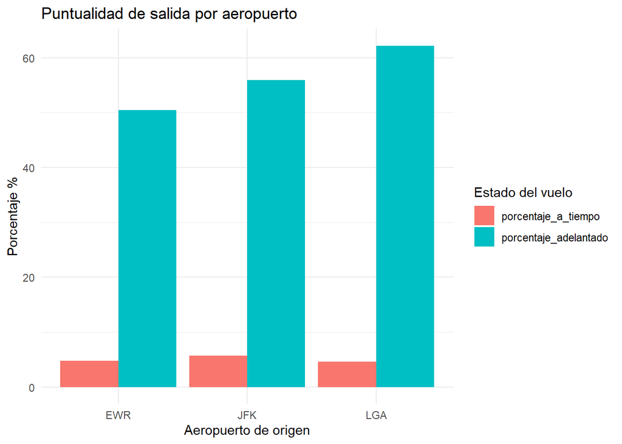

```r
library(tidyr) #para reorganizar datos
library(ggplot2) #graficar datos

vuelos_plot <- vuelos_puntuales %>%
  pivot_longer(  #convierte los datos de ancho a largo
    cols = starts_with("porcentaje"), #se selecciona todas las columnas cuyos nombres comienzan con porcentaje
    names_to = "puntualidad", #crea una columna llamada estado
    values_to = "porcentaje" )#crea esta columna donde se guardan los datos

ggplot(vuelos_plot, aes(x = origin, y = porcentaje, fill = puntualidad)) +
  geom_bar(stat = "identity", position = "dodge") + #dogge pone las barras lado a lado
  theme_minimal() +

  labs(title = "Puntualidad de salida por aeropuerto",
    x = "Aeropuerto de origen",
    y = "Porcentaje %",
    fill = "Estado del vuelo")
```

- la mayor parte de los vuelos puntuales corresponden a vuelos que salieron antes de la hora programada.
- el porcentaje de vuelos que despegaron exactamente a tiempo es menor.
- el aeropuerto LGA presentó el mayor porcentaje de vuelos adelantados.

## 14. ¿Qué aeropuertos de destino tienen el mayor retraso promedio en la llegada para vuelos desde NYC?

Haciendo el mismo procedimiento pero ahora con los vuelos de los aeropuestos de destino, en este caso seria la variable `dest`

```r
vuelos_tbl %>% #permite obtener la frecuencia de vuelos por aeropuerto de destino
  count(dest)
```

```
# Source:   SQL [?? x 2]
# Database: sqlite 3.52.0 [C:\Users\Latitude\Downloads\vuelos.db]
   dest      n
   <chr> <int>
 1 ABQ     254
 2 ACK     265
 3 ALB     439
 4 ANC       8
 5 ATL   17215
 6 AUS    2439
 7 AVL     275
 8 BDL     443
 9 BGR     375
10 BHM     297
# ℹ more rows
```

Podemos ver que son 105 destinos y hay destino mas frecuentes que otros.

```r
vuelos_tbl %>%
  select(arr_delay) %>% #se selecciona los retrasos de la llegada
  collect() %>% #traes los datos desde la base
  summary() #saca las estadisticas
```

```
   arr_delay
 Min.   : -86.000
 1st Qu.: -17.000
 Median :  -5.000
 Mean   :   6.895
 3rd Qu.:  14.000
 Max.   :1272.000
 NAs    :9430
```

- el valor minimo de -86, llegando antes de lo programado.
- el valor maximo de 1272 minutos, una cantidad considerable.
- la media es de 7 aprox que sugiere que en promedio, los vuelos tienden a llegar con retraso.
- la mediana es de -5 que indica que al menos la mitad de los vuelos llegan a tiempo o con cierto adelanto.
- la existencia de 9430 valores faltantes sugiere la presencia de registros sin informacion.

```r
vuelos_retraso <- vuelos_tbl %>%
  group_by(dest) %>% #agrupa los vuelos por aeropuerto de destino
  summarise(
    retraso_prom = mean(arr_delay, na.rm = TRUE), #calcula el retraso promedio en la llegada
   n_vuelos = n() # cuenta cuantos vuelos hay
  ) %>%
  arrange(desc(retraso_prom)) %>% #ordena de mayor a menor retraso promedio
  collect()
vuelos_retraso
```

```
# A tibble: 105 × 3
   dest  retraso_prom n_vuelos
   <chr>        <dbl>    <int>
 1 CAE           41.8      116
 2 TUL           33.7      315
 3 OKC           30.6      346
 4 JAC           28.1       25
 5 TYS           24.1      631
 6 MSN           20.2      572
 7 RIC           20.1     2454
 8 CAK           19.7      864
 9 DSM           19.0      569
10 GRR           18.2      765
# ℹ 95 more rows
```

Se incorporo el numero de vuelos por destino `n_vuelos` para evaluar la confiabilidad del retraso promedio, evitando conclusiones basadas en registros pequeños. Ahora consultemos en SQL para calcular el retraso promedio en la llegada por destino

```r
dbGetQuery(con, "
SELECT dest, --la columna aeropuerto de destino
       AVG(arr_delay) AS retraso_prom, --alcula el retraso promedio en la llegada
       COUNT(*) AS n_vuelos -- cuenta cuantos vuelos hay en cada destino
FROM flights  --de la tabla flights
GROUP BY dest --grupa todos los vuelos por aeropuerto de destino
ORDER BY retraso_prom DESC --ordena los resultados de mayor a menor
")
```

```
    dest retraso_prom n_vuelos
1    CAE  41.76415094      116
2    TUL  33.65986395      315
3    OKC  30.61904762      346
4    JAC  28.09523810       25
5    TYS  24.06920415      631
6    MSN  20.19604317      572
7    RIC  20.11125320     2454
8    CAK  19.69833729      864
9    DSM  19.00573614      569
10   GRR  18.18956044      765
11   BHM  16.87732342      297
12   PVD  16.23463687      376
13   GSP  15.93544304      849
14   CVG  15.36456376     3941
```

[output cut: 91 more lines]

- se identificaron los aeropuertos de destino con mayor retraso promedio en la llegada, destacando CAE, TUL y OKC como los aeropuestos mas afectados.
- sin embargo, se calculo el retraso promedio en la llegada junto con el numero de vuelos en cada caso, esto permite identificar los destinos con mayores retrasos y verificar si el resultado es confiable segun la cantidad de datos disponible.
- un promedio calculado con pocos datos puede no ser representativo, por ejemplo, aunque JAC presenta un retraso promedio elevado, cuenta con un numero reducido de vuelos, lo que puede generar mayor variabilidad en la estimacion.

```r
vuelos_retraso  %>%
  select(n_vuelos) %>%
  collect() %>%
  summary()
```

```
    n_vuelos
 Min.   :    1
 1st Qu.:  346
 Median : 1525
 Mean   : 3207
 3rd Qu.: 4113
 Max.   :17283
```

Ahora visualizamos dichos datos para comprender mejor la relacion entre el numero de vuelos y el retraso promedio en la llegada.

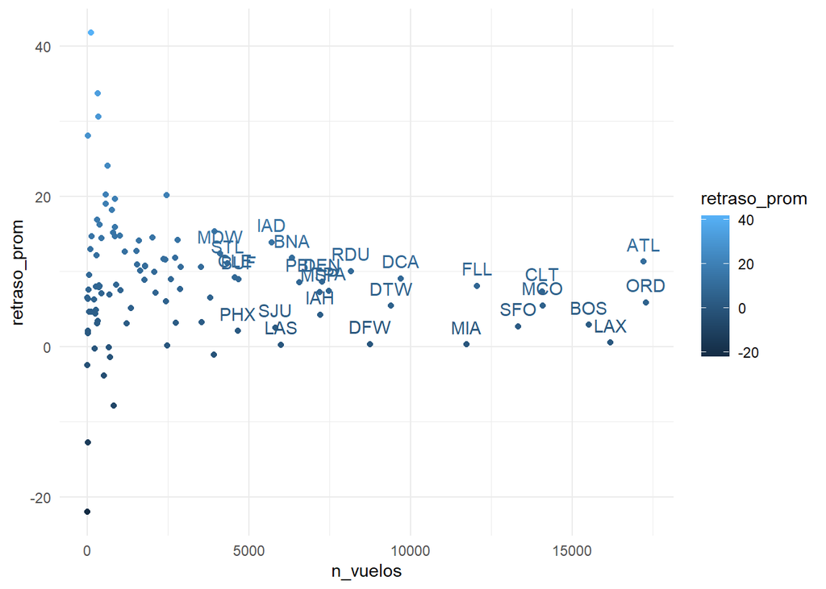

```r
ggplot(vuelos_retraso, aes(x = n_vuelos, y = retraso_prom, color= retraso_prom)) +
  geom_point() +
  geom_text(aes(label = ifelse(n_vuelos > 4000, dest, "")), #consideramos que 4000 tomando como referencia el tercer cuartil de n_vuelos
            vjust = -0.8) +
  theme_minimal()
```

Al considerar unicamente destinos con mas de 4000 vuelos, los retrasos promedio observados resultan mas confiables debido a un mayor tamaño de muestras

```r
vuelos_retraso %>%
  filter(n_vuelos > 4000) %>%
  arrange(desc(retraso_prom))
```

```
# A tibble: 27 × 3
   dest  retraso_prom n_vuelos
   <chr>        <dbl>    <int>
 1 IAD          13.9      5700
 2 MDW          12.4      4113
 3 BNA          11.8      6333
 4 ATL          11.3     17215
 5 STL          11.1      4339
 6 RDU          10.1      8163
 7 CLE           9.18     4573
 8 DCA           9.07     9705
 9 BUF           8.95     4681
10 DEN           8.61     7266
# ℹ 17 more rows
```

## 15. ¿Cómo varían los retrasos en la salida según la hora del día en cada aeropuerto de NYC?

Se sabe que `hour` y `minute` son componentes de la hora programada

```r
vuelos_tbl %>%  #seleccionamos solo las variables relevantes
  select(origin, hour,minute,time_hour, dep_delay) %>%
  head(30) %>% #mostramos unicamente las primeras 10 filas
  collect() #ejecutamos la consulta y traemos los datos a R
```

```
# A tibble: 30 × 5
   origin  hour minute  time_hour dep_delay
   <chr>  <dbl>  <dbl>      <dbl>     <dbl>
 1 EWR        5     15 1357034400         2
 2 LGA        5     29 1357034400         4
 3 JFK        5     40 1357034400         2
 4 JFK        5     45 1357034400        -1
 5 LGA        6      0 1357038000        -6
 6 EWR        5     58 1357034400        -4
 7 EWR        6      0 1357038000        -5
 8 LGA        6      0 1357038000        -3
 9 JFK        6      0 1357038000        -3
10 LGA        6      0 1357038000        -2
# ℹ 20 more rows
```

`minute` no se considera en el analisis, ya que el objetivo es evaluar el comportamiento de los retrasos a nivel de hora del dia y `time_hour` representa la fecha y hora del vuelo por lo cual no se usara, solo nos sirvio para explorar los datos.

```r
vuelos_tbl %>%
  summarise(n_na = sum(is.na(hour))) %>%
  collect()
```

```
# A tibble: 1 × 1
   n_na
  <int>
1     0
```

Verificamos si hay NAs `hour` y en este caso no hay.

```r
retrasos <- vuelos_tbl %>%
  group_by(origin, hour) %>% #agrupamos los datos por aeropuerto de origen y hora del dia
  summarise(
    retraso_prom = mean(dep_delay, na.rm = TRUE), #calculamos el retraso promedio
  .groups = "drop"
  ) %>%
  arrange(origin, hour) %>% #ordenamos los resultados para facilitar su lectura
  collect()
retrasos
```

```
# A tibble: 57 × 3
   origin  hour retraso_prom
   <chr>  <dbl>        <dbl>
 1 EWR        1       NA
 2 EWR        5        0.649
 3 EWR        6        3.50
 4 EWR        7        4.04
 5 EWR        8        5.50
 6 EWR        9        5.84
 7 EWR       10        7.79
 8 EWR       11        7.96
 9 EWR       12       11.6
10 EWR       13       13.6
# ℹ 47 more rows
```

- el valor NA en la hora 1 en el aeropuerto EWR que indica que no se dispone de informacin suficiente para calcular el retraso promedio en ese horario, posiblemente debido a la ausencia de vuelos registrados.

Ahora consultando en SQL:

```r
dbGetQuery(con, "
SELECT origin, hour, --eligimos aeropuerto y hora
AVG(dep_delay) AS retraso_prom --calculamos el retraso promedio
FROM flights
GROUP BY origin, hour  --agrupamos por aeropuesto de origen y la hora
ORDER BY origin, hour  --ordenamos por aeropuesto de origen y la hora
")
```

```
   origin hour retraso_prom
1     EWR    1           NA
2     EWR    5    0.6491031
3     EWR    6    3.4951182
4     EWR    7    4.0436768
5     EWR    8    5.4994514
6     EWR    9    5.8439846
7     EWR   10    7.7912038
8     EWR   11    7.9616561
9     EWR   12   11.6229179
10    EWR   13   13.6083727
11    EWR   14   17.4188912
12    EWR   15   20.5886150
13    EWR   16   23.0646922
14    EWR   17   25.3257558
```

[output cut: 43 more lines]

Coincide con la informacion antes obtenida.

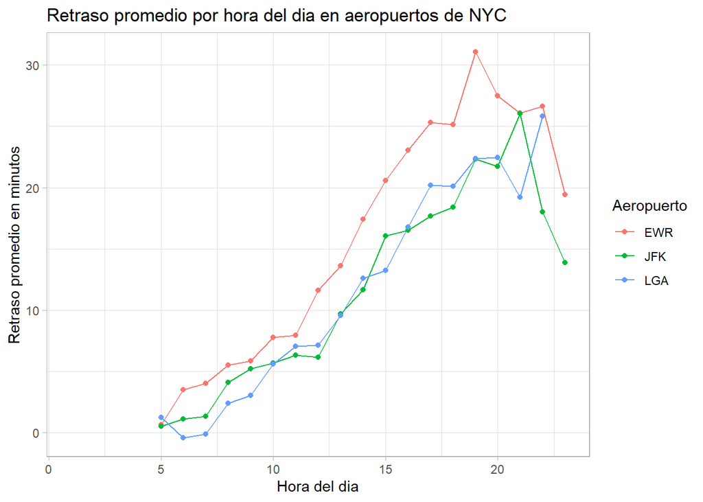

```r
retrasos %>%
  ggplot(aes(x = hour, y = retraso_prom, color = origin)) +
  geom_line() + # linea para ver la tendencia
  geom_point() + #puntos para cada observación

  labs( title = "Retraso promedio por hora del dia en aeropuertos de NYC",
    x = "Hora del dia",
    y = "Retraso promedio en minutos",
    color = "Aeropuerto") +

  theme_light()
```

## 16. ¿Cuál es la correlación entre la velocidad del viento y los retrasos en la salida?

Para esta pregunta nos es importante saber en que tabla de la base de datos está la información que requerimos. En este caso, nuestra información está en la tabla de clima y vuelos. Vuelos para el tiempo de retraso de salida y clima para la temperatura, velocidad de viento y lluvia.

```r
dbListTables(con)
```

```
[1] "airlines" "airports" "flights"  "planes"   "weather"
```

Siempre es bueno efectuar una lectura de nuestra tabla para conocer las variables y saber como mandar a llamarlas:

```r
#llamamos a la tabla clima con dplyr
clima <- dbReadTable(con,"weather")
head(clima)
```

```
  origin year month day hour  temp  dewp humid wind_dir wind_speed wind_gust
1    EWR 2013     1   1    1 39.02 26.06 59.37      270   10.35702        NA
2    EWR 2013     1   1    2 39.02 26.96 61.63      250    8.05546        NA
3    EWR 2013     1   1    3 39.02 28.04 64.43      240   11.50780        NA
4    EWR 2013     1   1    4 39.92 28.04 62.21      250   12.65858        NA
5    EWR 2013     1   1    5 39.02 28.04 64.43      260   12.65858        NA
6    EWR 2013     1   1    6 37.94 28.04 67.21      240   11.50780        NA
  precip pressure visib  time_hour
1      0   1012.0    10 1357020000
2      0   1012.3    10 1357023600
3      0   1012.5    10 1357027200
4      0   1012.2    10 1357030800
5      0   1011.9    10 1357034400
6      0   1012.4    10 1357038000
```

```r
#llamamos a la tabla clima con sql
clima2 <- dbGetQuery(con, "SELECT * FROM weather")
head(clima2)
```

```
  origin year month day hour  temp  dewp humid wind_dir wind_speed wind_gust
1    EWR 2013     1   1    1 39.02 26.06 59.37      270   10.35702        NA
2    EWR 2013     1   1    2 39.02 26.96 61.63      250    8.05546        NA
3    EWR 2013     1   1    3 39.02 28.04 64.43      240   11.50780        NA
4    EWR 2013     1   1    4 39.92 28.04 62.21      250   12.65858        NA
5    EWR 2013     1   1    5 39.02 28.04 64.43      260   12.65858        NA
6    EWR 2013     1   1    6 37.94 28.04 67.21      240   11.50780        NA
  precip pressure visib  time_hour
1      0   1012.0    10 1357020000
2      0   1012.3    10 1357023600
3      0   1012.5    10 1357027200
4      0   1012.2    10 1357030800
5      0   1011.9    10 1357034400
6      0   1012.4    10 1357038000
```

```r
#creamos las tablas vuelos y clima como tablas
vuelos_db <- tbl(con, "flights")
clima_db <- tbl(con, "weather")
```

Ahora que ya conocemos los contenidos, nos conviene hacer un join de dep_delay (retraso de salida) y wind_speed (velocidad del aire) usando dplyr y sql:

```r
#hacemos join con dplyr que contará con wind_speed y dep_delay
datclim_vuelos <- vuelos_db %>% #creamos la nueva tabla datclim_vuelos
  inner_join(clima_db, #hacemos el join con la tabla clima
             by = c("origin", "year", "month", "day", "hour"))%>% #tomando el vector origen, año, mes, día y hora para empatar los vuelos
  filter(!is.na(dep_delay), !is.na(wind_speed)) %>%
  #filtramos el tiempo de salida y velocidad de viento
  select(flight,origin, dep_delay, wind_speed) #hace el join de salida y velocidad de viento

datclim_vuelos #crea la tabla con las dos variables de importancia
```

```
# Source:   SQL [?? x 4]
# Database: sqlite 3.52.0 [C:\Users\Latitude\Downloads\vuelos.db]
   flight origin dep_delay wind_speed
    <int> <chr>      <dbl>      <dbl>
 1   1545 EWR            2       12.7
 2   1714 LGA            4       15.0
 3   1141 JFK            2       15.0
 4    725 JFK           -1       15.0
 5    461 LGA           -6       16.1
 6   1696 EWR           -4       12.7
 7    507 EWR           -5       11.5
 8   5708 LGA           -3       16.1
 9     79 JFK           -3       13.8
10    301 LGA           -2       16.1
# ℹ more rows
```

Para calcular la correlación de cualquier dato, usaremos la correlación de Pearson:

$r=\frac{\sum_{i=1}^{n}(x_{i}-\bar{x})(y_{i}-\bar(y))}{\sqrt{\sum_{i=1}^{n}(x_{i}-\bar{x})^{2}}\sqrt{\sum_{i=1}^{n}(y_{i}-\bar{y})^{2}}}$

```r
#hacemos join con sql y buscamos la correlación
#llamamos a esta tabla cor_sql
#seleccionamos origen, hacemos conteo total de vuelos
#aplicamos la correlación de pearson entre retraso de salida y velocidad de viento
cor_sql <- "
SELECT
  v.origin,
  COUNT(*) as total_vuelos,
  (AVG(v.dep_delay * c.wind_speed) - AVG(v.dep_delay) * AVG(c.wind_speed)) /
  (SQRT(AVG(v.dep_delay * v.dep_delay) - AVG(v.dep_delay) * AVG(v.dep_delay)) *
   SQRT(AVG(c.wind_speed * c.wind_speed) - AVG(c.wind_speed) * AVG(c.wind_speed))) AS correlacion
FROM flights v
INNER JOIN weather c
  ON v.origin = c.origin
  AND v.year = c.year
  AND v.month = c.month
  AND v.day = c.day
  AND v.hour = c.hour
WHERE v.dep_delay > 1
  AND v.dep_delay IS NOT NULL
  AND c.wind_speed IS NOT NULL
GROUP BY v.origin
"
#el join se hace en el inner join
#agrupamos conforme al origen
#y tomamos el valor de velocidad de viento
#los retrasos lo tomamos para dep_delay mayor a un minuto
resultado_sql <- dbGetQuery(con, cor_sql)
resultado_sql
```

```
  origin total_vuelos correlacion
1    EWR        49129 0.025642444
2    JFK        39065 0.044174792
3    LGA        31543 0.008047059
```

```r
#hacemos la correlación con dplyr
#tomando la tabla con el join de dplyr
corr_viento_ret <- datclim_vuelos %>% #usamos la tabla datclim_vuelos
  filter(dep_delay > 1, !is.na(dep_delay), !is.na(wind_speed)) %>%
  #filtramos con tiempo mayor a 1 y con las velocidad del viento en ello
  group_by(origin) %>% #tommamos en cuenta el origen
  summarise(
    total_vuelos = n(),
    #hace el calculo de la correlación de pearson
    correlacion = (mean(dep_delay * wind_speed) - mean(dep_delay) * mean(wind_speed)) /
                  (sqrt(mean(dep_delay^2) - mean(dep_delay)^2) *
                   sqrt(mean(wind_speed^2) - mean(wind_speed)^2))
  ) %>%
  collect()

corr_viento_ret
```

```
# A tibble: 3 × 3
  origin total_vuelos correlacion
  <chr>         <int>       <dbl>
1 EWR           49129     0.0256
2 JFK           39065     0.0442
3 LGA           31543     0.00805
```

Lo que vemos en la tabla es que no hay correlación con la velocidad del viento y la salida de los aviones. Por así decirlo, el aeropuerto más afectado por ello es el JFK.

## 17. ¿Los vuelos experimentan más retrasos en días con lluvias intensas?

Hacemos los mismo que con anterioridad, pero nuestra sospecha será vista con retrasos de tiempo mayor a 1 y 30 minutos con precipitaciones mayores a 0.5.

Por ende, usando Pearson y haciendo el cálculo con dplyr y sql tenemos lo siguiente.

Primero, hacemos join de los datos de dep_delay y precip:

```r
#hacemos join con clima_db y vuelos
datclim_vuelos <- vuelos_db %>%
  inner_join(clima_db,
             by = c("origin", "year", "month", "day", "hour"))%>%
  filter(!is.na(dep_delay), !is.na(precip)) %>%
  select(flight,origin, dep_delay, precip)
#solo tomamos los datos de vuelo, origen, tiempo de salida de retardo y precipitación
head(datclim_vuelos) #nos muestra la tabla con join
```

```
# Source:   SQL [?? x 4]
# Database: sqlite 3.52.0 [C:\Users\Latitude\Downloads\vuelos.db]
  flight origin dep_delay precip
   <int> <chr>      <dbl>  <dbl>
1   1545 EWR            2      0
2   1714 LGA            4      0
3   1141 JFK            2      0
4    725 JFK           -1      0
5    461 LGA           -6      0
6   1696 EWR           -4      0
```

Consecuentemente, calculamos los coeficientes de correlación en sql y dplyr:

```r
#hacemos la correlación en sql e internal join
#seleccionamos origen
#contamos el total de vuelos
#aplicamos orrelación de pearson
#tomamos los vuelos de vuelos.db
#hacemos join con clima y precip tomando en cuenta año, día, mes y hora
cor_sql <- "
SELECT
  v.origin,
  COUNT(*) as total_vuelos,
  (AVG(v.dep_delay * c.precip) - AVG(v.dep_delay) * AVG(c.precip)) /
  (SQRT(AVG(v.dep_delay * v.dep_delay) - AVG(v.dep_delay) * AVG(v.dep_delay)) *
   SQRT(AVG(c.precip * c.precip) - AVG(c.precip) * AVG(c.precip))) AS correlacion
FROM flights v
INNER JOIN weather c
  ON v.origin = c.origin
  AND v.year = c.year
  AND v.month = c.month
  AND v.day = c.day
  AND v.hour = c.hour
WHERE v.dep_delay > 30 AND c.precip > 0.5
  AND v.dep_delay IS NOT NULL
  AND c.precip IS NOT NULL
GROUP BY v.origin
"
#usamos las tiempos mayor a 30 minutos
#agrupa los vuelos or su origen
#pedimos el qery con los facotres de correlación
resultado_sql <- dbGetQuery(con, cor_sql)
resultado_sql
```

```
  origin total_vuelos correlacion
1    EWR           20   0.4376676
2    JFK            5   0.3275958
3    LGA           30   0.3072097
```

```r
#hacemos la correlación en sql e internal join
#seleccionamos origen
#contamos el total de vuelos
#aplicamos orrelación de pearson
#tomamos los vuelos de vuelos.db
#hacemos join con clima y precip tomando en cuenta año, día, mes y hora
cor_sql <- "
SELECT
  v.origin,
  COUNT(*) as total_vuelos,
  (AVG(v.dep_delay * c.precip) - AVG(v.dep_delay) * AVG(c.precip)) /
  (SQRT(AVG(v.dep_delay * v.dep_delay) - AVG(v.dep_delay) * AVG(v.dep_delay)) *
   SQRT(AVG(c.precip * c.precip) - AVG(c.precip) * AVG(c.precip))) AS correlacion
FROM flights v
INNER JOIN weather c
  ON v.origin = c.origin
  AND v.year = c.year
  AND v.month = c.month
  AND v.day = c.day
  AND v.hour = c.hour
WHERE v.dep_delay > 1 AND c.precip > 0.5
  AND v.dep_delay IS NOT NULL
  AND c.precip IS NOT NULL
GROUP BY v.origin
"
#usamos las tiempos mayor a 30 minutos
#agrupa los vuelos or su origen
#pedimos el qery con los facotres de correlación

resultado_sql <- dbGetQuery(con, cor_sql)
resultado_sql
```

```
  origin total_vuelos correlacion
1    EWR           43   0.4968333
2    JFK           10  -0.4278711
3    LGA           41   0.1936171
```

```r
#calculamos la correlación con tiempos myores a un minuto
corr_precip_ret <- datclim_vuelos %>% #seleccionamos los valores de dat_clim
  filter(precip>0.5, !is.na(dep_delay)) %>% #filtramos para precipitaciones
  #mayores de 0.5
  filter(dep_delay > 1, !is.na(dep_delay), !is.na(precip)) %>%
  #filtramos para tiempo de retardos mayor al minutos
  group_by(origin) %>% #agrupamos por origen
  summarise(
    #calculamos correlación de pearson
    total_vuelos = n(),
    correlacion = (mean(dep_delay * precip) - mean(dep_delay) * mean(precip)) /
                  (sqrt(mean(dep_delay^2) - mean(dep_delay)^2) *
                   sqrt(mean(precip^2) - mean(precip)^2))
  ) %>%
  collect()
#nos arroja los coeficientes de correlación
corr_precip_ret
```

```
# A tibble: 3 × 3
  origin total_vuelos correlacion
  <chr>         <int>       <dbl>
1 EWR              43       0.497
2 JFK              10      -0.428
3 LGA              41       0.194
```

```r
#calculamos para tiempos de retardo de más 30 minutos
corr_precip_ret <- datclim_vuelos %>% #usamos la tabla de datclima_vuelos
  filter(precip>0.5, !is.na(dep_delay)) %>% #filtramos para precip mayor a 0.5
  filter(dep_delay > 30, !is.na(dep_delay), !is.na(precip)) %>%
  #filtramos para tiempo de retraso mayor a 30 minutos
  group_by(origin) %>% #agrupamos por origen
  summarise(
    #calculamos la correlación de pearson
    total_vuelos = n(),
    correlacion = (mean(dep_delay * precip) - mean(dep_delay) * mean(precip)) /
                  (sqrt(mean(dep_delay^2) - mean(dep_delay)^2) *
                   sqrt(mean(precip^2) - mean(precip)^2))
  ) %>%
  collect()
#nos muestra la correlación
corr_precip_ret
```

```
# A tibble: 3 × 3
  origin total_vuelos correlacion
  <chr>         <int>       <dbl>
1 EWR              20       0.438
2 JFK               5       0.328
3 LGA              30       0.307
```

En conlusión EWR para retrasos de mayores a un minuto tiene un coeficiente de correlación de 0.49 y para tiempos mayores a treinta minutos es de 0.43; para JFK los retrasos de mayores a un minuto tiene un coeficiente de correlación de -0.42 y para tiempos mayores treinta minutos de 0.32; para LGA los retrasos de mayores a un minuto tiene un coeficiente de correlación de 0.19 y para tiempos mayores a treinta minutos de 0.30.

Aún así, la correlación es baja.

## 18. ¿Cómo afecta la temperatura a los retrasos de los vuelos?

Al igual que la pregunta 16 y 17, haremos join con vuelos y clima, en este caso para la temperatura como se muestra a continuación:

```r
#hacemos join de la tabla vuelos con temperaturaa
datclim_vuelos <- vuelos_db %>%
  inner_join(clima_db, #de la tabla clima relacionamos año, mes, día y hora
             by = c("origin", "year", "month", "day", "hour"))%>%
  filter(!is.na(dep_delay), !is.na(temp)) %>% #tomamos el valor de temperatura
  select(flight,origin, dep_delay, temp)
#creamos una tabla con el nombre de vuelo, origen, tiempo de retraso de salida y temperatura
datclim_vuelos
```

```
# Source:   SQL [?? x 4]
# Database: sqlite 3.52.0 [C:\Users\Latitude\Downloads\vuelos.db]
   flight origin dep_delay  temp
    <int> <chr>      <dbl> <dbl>
 1   1545 EWR            2  39.0
 2   1714 LGA            4  39.9
 3   1141 JFK            2  39.0
 4    725 JFK           -1  39.0
 5    461 LGA           -6  39.9
 6   1696 EWR           -4  39.0
 7    507 EWR           -5  37.9
 8   5708 LGA           -3  39.9
 9     79 JFK           -3  37.9
10    301 LGA           -2  39.9
# ℹ more rows
```

Una vez hecho el join, hacemos el cálculo de correlación con sql y dplyr usando coeficiente de pearson:

```r
#correlación de Pearson en sql para temperatura
#seleccionamos la variable origen
#pedimos el calculo del coeficiente de peason
cor_sql <- "
SELECT
  v.origin,
  COUNT(*) as total_vuelos,
  (AVG(v.dep_delay * c.temp) - AVG(v.dep_delay) * AVG(c.temp)) /
  (SQRT(AVG(v.dep_delay * v.dep_delay) - AVG(v.dep_delay) * AVG(v.dep_delay)) *
   SQRT(AVG(c.temp * c.temp) - AVG(c.temp) * AVG(c.temp))) AS correlacion
FROM flights v
INNER JOIN weather c
  ON v.origin = c.origin
  AND v.year = c.year
  AND v.month = c.month
  AND v.day = c.day
  AND v.hour = c.hour
WHERE v.dep_delay > 1
  AND v.dep_delay IS NOT NULL
  AND c.temp IS NOT NULL
GROUP BY v.origin
"
#de vuelos hacemos join con clima y la variable temperatura
#tomamos retardos mayores a un minutos
#relacionamos la hora, año, mes y día para empatar la tabla
resultado_sql <- dbGetQuery(con, cor_sql)
resultado_sql #nos arroja el coeficiente de pearson
```

```
  origin total_vuelos correlacion
1    EWR        49125  0.04374017
2    JFK        39081  0.06777103
3    LGA        31543  0.10382136
```

```r
#hacemos la correlación con el join de dplyr entre temp y dep_delay
corr_temp_ret <- datclim_vuelos %>% #llamamos a al nueva tabla correlacion
  #de temperatura
  #filter(precip>0.5, !is.na(dep_delay)) %>%
  filter(dep_delay > 1, !is.na(dep_delay), !is.na(temp)) %>%
  #filtramos para tiempos mayores a un minuto
  group_by(origin) %>%
  #agrupamos con origen
  summarise(
    total_vuelos = n(),
    correlacion = (mean(dep_delay * temp) - mean(dep_delay) * mean(temp)) /
                  (sqrt(mean(dep_delay^2) - mean(dep_delay)^2) *
                   sqrt(mean(temp^2) - mean(temp)^2))
  #calculamos el coeficiente de pearson
  ) %>%
  collect()
#nos arroja los coeficientes de correlación
corr_temp_ret
```

```
# A tibble: 3 × 3
  origin total_vuelos correlacion
  <chr>         <int>       <dbl>
1 EWR           49125      0.0437
2 JFK           39081      0.0678
3 LGA           31543      0.104
```

Vemos que prácticamente no influye en nada el clima en el retraso de salida de los vuelos. En todo caso, el que más se ve afectado es LGA con un coeficiente de Pearson de $0.10$. Mientras EWR tiene un coeficiente de Pearson de $0.04$ y JFK tiene un coeficiente de $0.06$. Debe influir otros facotres como niebla o nevada.

## 19. ¿Cómo afectan los niveles de visibilidad a los retrasos en la llegada?

```r
# Seleccionamos la columna visb de la tabla clima, obtenemos el promedio en los retrasos de llegada y usaremos COUNT(*) para contar todos los renglones y ya que agrupamos en base a la columna visb lo que estamos haciendo es contar cuantos registros hay de cada nivel de visibilidad, lo cual nos ayudara a ver cuantos vuelos tuvieron ese nivel de visibilidad.

# Tambien realizamos un JOIN para poder unir nuestras columnas de interes
dbGetQuery(con, "SELECT c.visib AS visibilidad, AVG(v.arr_delay) AS retraso_promedio, COUNT(*) AS total_vuelos
FROM flights v
JOIN weather c
  ON v.origin = c.origin
  AND v.time_hour = c.time_hour
GROUP BY c.visib
ORDER BY c.visib DESC")
```

```
   visibilidad retraso_promedio total_vuelos
1        10.00          4.32024       278739
2         9.00         15.58283        11436
3         8.00         16.04196         7614
4         7.00         16.34935         7347
5         6.00         17.12885         6260
6         5.00         18.91926         4809
7         4.00         17.71422         2253
8         3.00         21.67750         3624
9         2.50         21.73157         2434
10        2.00         26.29129         3199
11        1.75         45.56818          156
12        1.50         34.67340         1692
13        1.25         65.12849          208
14        1.00         37.60180         1474
15        0.75         41.35681          496
16        0.50         39.80213         1478
17        0.25         20.81889         1358
18        0.12         45.35980          440
19        0.06         28.48810           93
20        0.00         24.91954          110
```

```r
datos_clima <- dbGetQuery(con, "SELECT * FROM weather")
datos_clima
```

```
     origin year month day hour   temp  dewp  humid wind_dir wind_speed
1       EWR 2013     1   1    1  39.02 26.06  59.37      270   10.35702
2       EWR 2013     1   1    2  39.02 26.96  61.63      250    8.05546
3       EWR 2013     1   1    3  39.02 28.04  64.43      240   11.50780
4       EWR 2013     1   1    4  39.92 28.04  62.21      250   12.65858
5       EWR 2013     1   1    5  39.02 28.04  64.43      260   12.65858
6       EWR 2013     1   1    6  37.94 28.04  67.21      240   11.50780
7       EWR 2013     1   1    7  39.02 28.04  64.43      240   14.96014
8       EWR 2013     1   1    8  39.92 28.04  62.21      250   10.35702
9       EWR 2013     1   1    9  39.92 28.04  62.21      260   14.96014
10      EWR 2013     1   1   10  41.00 28.04  59.65      260   13.80936
11      EWR 2013     1   1   11  41.00 26.96  57.06      260   14.96014
12      EWR 2013     1   1   13  39.20 28.40  69.67      330   16.11092
13      EWR 2013     1   1   14  39.02 24.08  54.68      280   13.80936
14      EWR 2013     1   1   15  37.94 24.08  57.04      290    9.20624
```

[output cut: 13320 more lines]

```r
datos_vuelos |>
  # Juntamos ambas tablabas
  inner_join(datos_clima,c("origin", "time_hour")) |>
  # Filtramos los datos que no sean NA's
  filter(!is.na(arr_delay)) |>
  # Agrupamos por la columna de visibilidad
  group_by(visib) |>
  # Obtenemos el promedio en retrasos de llegada y contamos cuantos vuelos hubo
  # en cada nivel de visibilidad
  summarise(
    promedio_retrasos = mean(arr_delay, na.rm = TRUE), total_vuelos = n()) |>
  arrange(desc(visib))
```

```
# A tibble: 20 × 3
   visib promedio_retrasos total_vuelos
   <dbl>             <dbl>        <int>
 1 10                 4.32       272802
 2  9                15.6         10914
 3  8                16.0          7268
 4  7                16.3          6970
 5  6                17.1          5914
 6  5                18.9          4533
 7  4                17.7          2117
 8  3                21.7          3355
 9  2.5              21.7          2265
10  2                26.3          2894
11  1.75             45.6           132
12  1.5              34.7          1534
13  1.25             65.1           179
14  1                37.6          1336
15  0.75             41.4           426
16  0.5              39.8          1314
17  0.25             20.8          1292
18  0.12             45.4           403
19  0.06             28.5            84
20  0                24.9            87
```

En ambos dataframes podemos ver que efectivamente conforme empeora la visibilidad comienza a aumentar el retraso en la llegada de los vuelos.

## 20. ¿La alta humedad se relaciona de alguna manera con los tiempos de taxi-out más largos?

```r
taxi_out_humedad <- datos_vuelos %>%
  # 1. Unimos con aeropuertos para el tz
  left_join(datos_aeropuertos, by = c("dest" = "faa")) %>%
  # 2. UNIÓN CRÍTICA: Unimos con la tabla de clima (weather)
  # Usamos origin, year, month, day y hour para que coincida el clima del despegue
  left_join(datos_clima, by = c("origin", "year", "month", "day", "hour")) %>%
  # Filtramos NAs incluyendo la nueva columna 'humid'
  filter(!is.na(air_time), !is.na(dep_time), !is.na(arr_time), !is.na(humid)) %>%
  mutate(
    dep_min = (dep_time %/% 100) * 60 + (dep_time %% 100),
    arr_min = (arr_time %/% 100) * 60 + (arr_time %% 100),
    diferencia_tz = (tz + 5) * 60,
    arr_min_ajustado = arr_min - diferencia_tz,
    arr_min_ajustado = ifelse(arr_min_ajustado < dep_min, arr_min_ajustado + 1440,      arr_min_ajustado),
    taxi_out_aprox = (arr_min_ajustado - air_time) - dep_min,

    # Esto lo hacemos para agrupar los porcentajes de humedad
    # Por ejemplo, los porcentajes 11%, 15%, 19%, etc. lo agrupamos todo
    # en el rango "10"
    rango_humedad = (humid %/% 10) * 10) %>%
  filter(taxi_out_aprox > 0)

# Agrupamos por humedad y calculamos los promedios de taxi-out
resultado_humedad <- taxi_out_humedad %>%
  group_by(rango_humedad) %>%
  summarise(taxi_out_promedio = mean(taxi_out_aprox)) %>%
  arrange(rango_humedad)

resultado_humedad
```

```
# A tibble: 10 × 2
   rango_humedad taxi_out_promedio
           <dbl>             <dbl>
 1            10              31.1
 2            20              30.6
 3            30              30.2
 4            40              30.4
 5            50              30.2
 6            60              31.0
 7            70              32.1
 8            80              33.7
 9            90              34.9
10           100              33.3
```

```r
# Hacemos un pequeño ajuste a los datos de humedad para poder agruparlos en rangos de 10%

# Despues calculamos el taxi-out y luego agrupamos por los porcentajes de humedad
dbGetQuery(con, "SELECT
    -- Agrupamos la humedad en rangos de 10% para ver tendencias claras
    (CAST(c.humid / 10 AS INT) * 10) AS rango_humedad,
    AVG(CASE
            WHEN ((((v.arr_time / 100) * 60 + (v.arr_time % 100)) - (a.tz + 5) * 60)                - ((v.dep_time / 100) * 60 + (v.dep_time % 100))) < 0

            THEN ((((v.arr_time / 100) * 60 + (v.arr_time % 100)) - (a.tz + 5) * 60)                - ((v.dep_time / 100) * 60 + (v.dep_time % 100)) + 1440) - v.air_time

            ELSE ((((v.arr_time / 100) * 60 + (v.arr_time % 100)) - (a.tz + 5) * 60)                - ((v.dep_time / 100) * 60 + (v.dep_time % 100))) - v.air_time
        END) AS taxi_out_promedio
FROM
    flights v
JOIN
    airports a ON v.dest = a.faa
JOIN
    weather c ON v.origin = c.origin
              AND v.year = c.year
              AND v.month = c.month
              AND v.day = c.day
              AND v.hour = c.hour
WHERE
    v.dep_time IS NOT NULL
    AND v.arr_time IS NOT NULL
    AND v.air_time IS NOT NULL
    AND c.humid IS NOT NULL
GROUP BY
    rango_humedad
ORDER BY
    rango_humedad")
```

```
   rango_humedad taxi_out_promedio
1             10          30.08040
2             20          29.92719
3             30          29.38962
4             40          29.83628
5             50          29.55482
6             60          30.38388
7             70          31.37683
8             80          33.01212
9             90          34.15501
10           100          32.86961
```

En ambas tablas podemos ver que hay ligeros aumentos en el taxi-out cuando la humedad es mayor, asi que podriamos decir que la humedad si esta un poco relacionada con los tiempos mayores de taxi-out, pero pede que no sea un factor con demasiado peso para que aumente el taxi-out.